# DGS_S1_analyses

### Duration..in.seconds.

#### Distribution

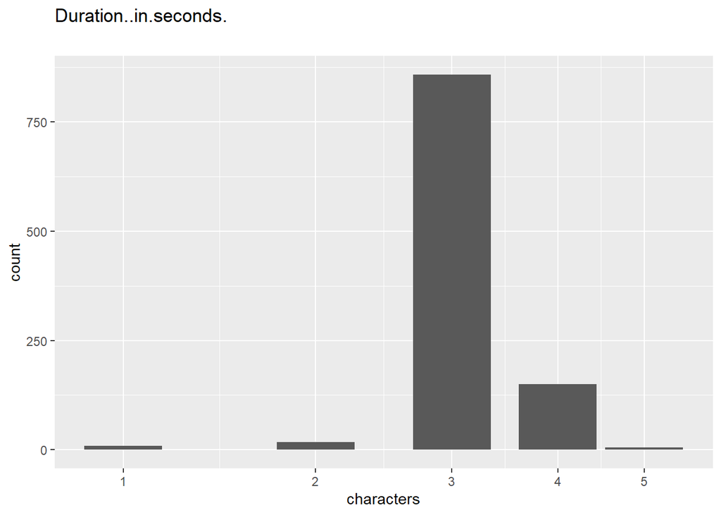

Distribution of values for Duration..in.seconds.

0 missing values.

#### Summary statistics

| name | data_type | n_missing | complete_rate | n_unique | empty | min | max | whitespace | label |
| --- | --- | --- | --- | --- | --- | --- | --- | --- | --- |
| Duration..in.seconds. | character | 0 | 1 | 650 | 0 | 1 | 5 | 0 | NA |

### Finished

#### Distribution

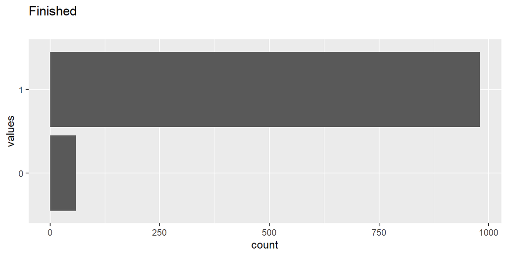

Distribution of values for Finished

0 missing values.

#### Summary statistics

| name | data_type | n_missing | complete_rate | n_unique | empty | min | max | whitespace | label |
| --- | --- | --- | --- | --- | --- | --- | --- | --- | --- |
| Finished | character | 0 | 1 | 2 | 0 | 1 | 1 | 0 | NA |

### DistributionChannel

#### Distribution

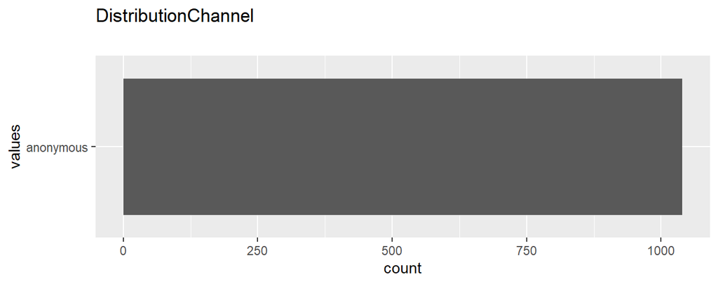

Distribution of values for DistributionChannel

0 missing values.

#### Summary statistics

| name | data_type | n_missing | complete_rate | n_unique | empty | min | max | whitespace | label |
| --- | --- | --- | --- | --- | --- | --- | --- | --- | --- |
| DistributionChannel | character | 0 | 1 | 1 | 0 | 9 | 9 | 0 | NA |

### UserLanguage

#### Distribution

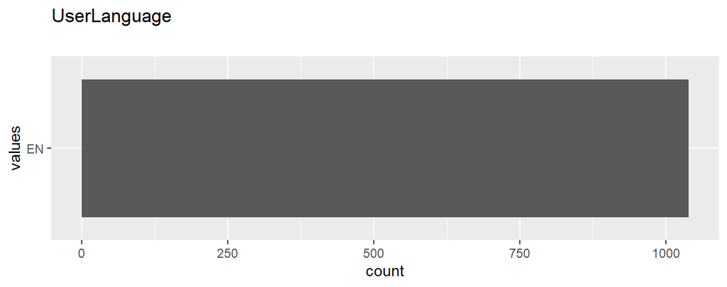

Distribution of values for UserLanguage

0 missing values.

#### Summary statistics

| name | data_type | n_missing | complete_rate | n_unique | empty | min | max | whitespace | label |
| --- | --- | --- | --- | --- | --- | --- | --- | --- | --- |
| UserLanguage | character | 0 | 1 | 1 | 0 | 2 | 2 | 0 | NA |

### Consent

#### Distribution

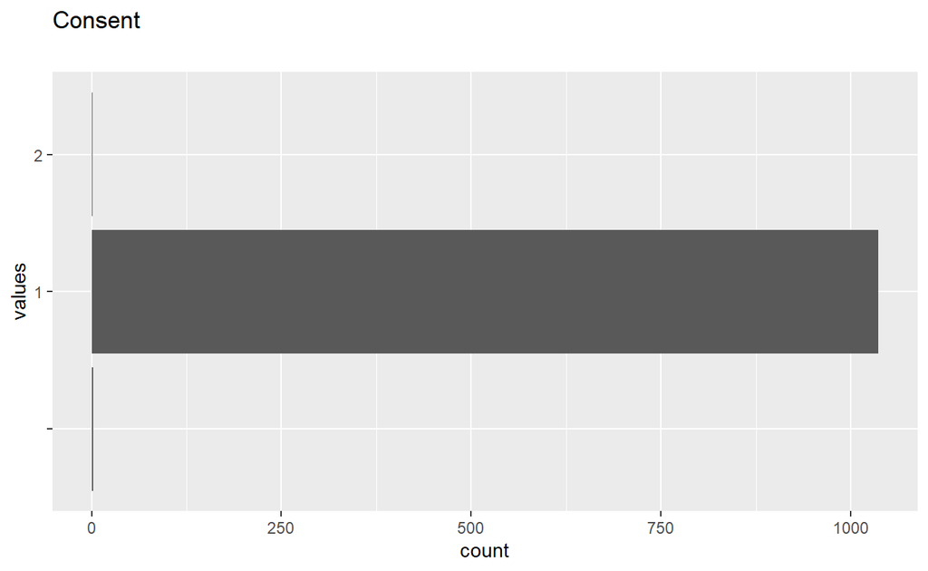

Distribution of values for Consent

0 missing values.

#### Summary statistics

| name | data_type | n_missing | complete_rate | n_unique | empty | min | max | whitespace | label |
| --- | --- | --- | --- | --- | --- | --- | --- | --- | --- |
| Consent | character | 0 | 1 | 3 | 2 | 0 | 1 | 0 | NA |

### DGS_31

Please choose “Neither agree nor disagree” for this question

#### Distribution

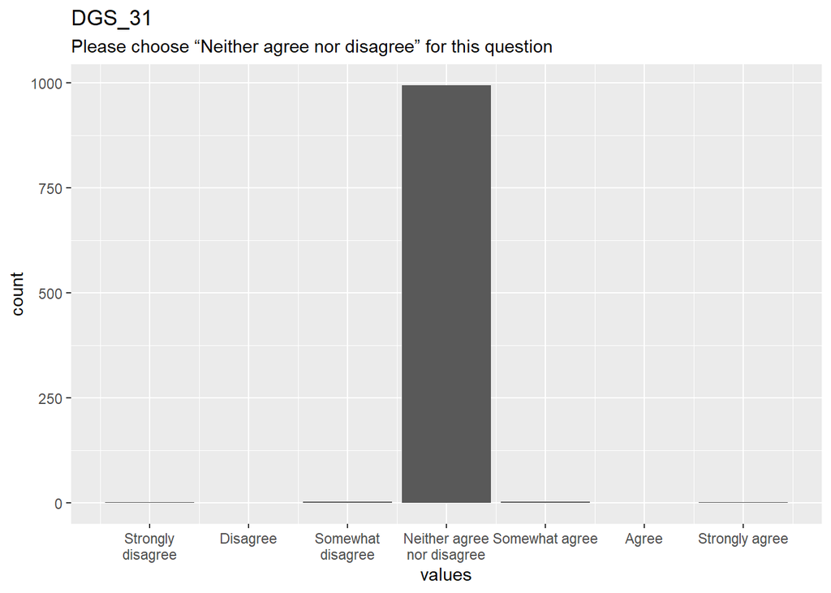

Distribution of values for DGS_31

33 missing values.

#### Summary statistics

| name | label | data_type | n_missing | complete_rate | min | median | max | mean | sd | n_value_labels | hist |
| --- | --- | --- | --- | --- | --- | --- | --- | --- | --- | --- | --- |
| DGS_31 | Please choose “Neither agree nor disagree” for this question | haven_labelled | 33 | 0.9682387 | 1 | 4 | 7 | 4 | 0.2230499 | 7 | ▁▁▁▇▁▁▁▁ |

#### Value labels

Response choices

| name | value |
| --- | --- |
| Strongly disagree | 1 |
| Disagree | 2 |
| Somewhat disagree | 3 |
| Neither agree nor disagree | 4 |
| Somewhat agree | 5 |
| Agree | 6 |
| Strongly agree | 7 |

### DGS_53

Please choose “Disagree” for this question

#### Distribution

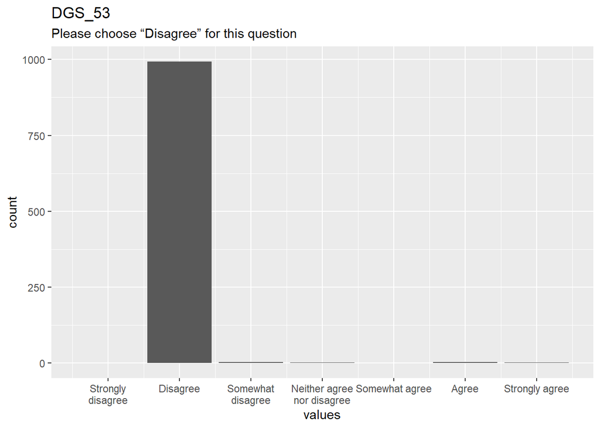

Distribution of values for DGS_53

33 missing values.

#### Summary statistics

| name | label | data_type | n_missing | complete_rate | min | median | max | mean | sd | n_value_labels | hist |
| --- | --- | --- | --- | --- | --- | --- | --- | --- | --- | --- | --- |
| DGS_53 | Please choose “Disagree” for this question | haven_labelled | 33 | 0.9682387 | 1 | 2 | 7 | 2.031809 | 0.3440787 | 7 | ▁▇▁▁▁▁▁▁ |

#### Value labels

Response choices

| name | value |
| --- | --- |
| Strongly disagree | 1 |
| Disagree | 2 |
| Somewhat disagree | 3 |
| Neither agree nor disagree | 4 |
| Somewhat agree | 5 |
| Agree | 6 |
| Strongly agree | 7 |

### Age

Please indicate your age in years.

#### Distribution

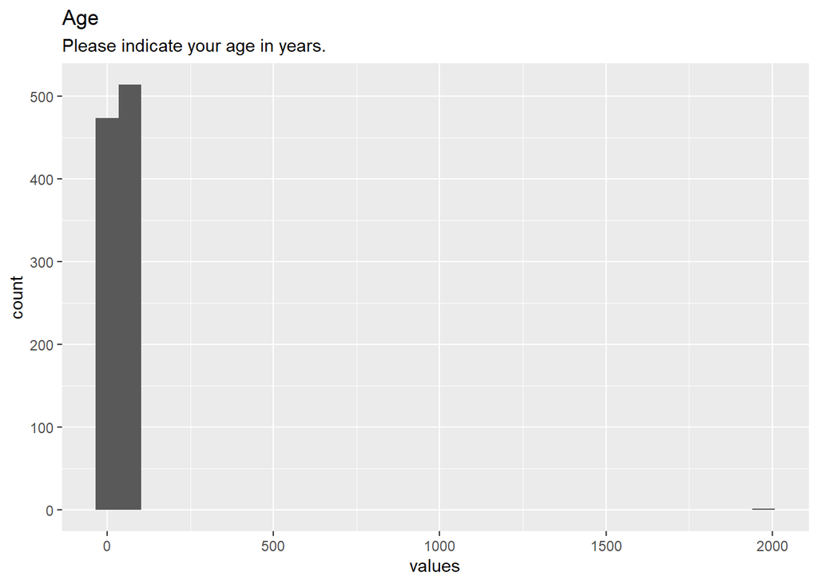

Distribution of values for Age

49 missing values.

#### Summary statistics

| name | label | data_type | n_missing | complete_rate | min | median | max | mean | sd | hist |
| --- | --- | --- | --- | --- | --- | --- | --- | --- | --- | --- |
| Age | Please indicate your age in years. | numeric | 49 | 0.9528393 | 18 | 35 | 1992 | 41.89596 | 88.51631 | ▇▁▁▁▁ |

### Gender

What gender do you identify as?

#### Distribution

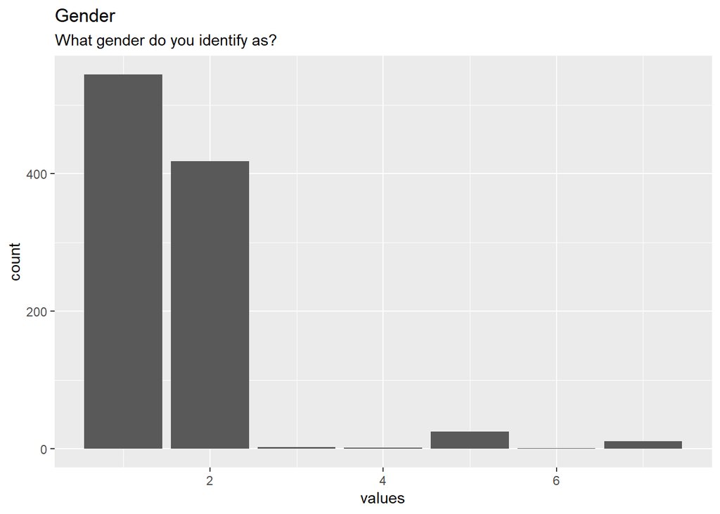

Distribution of values for Gender

35 missing values.

#### Summary statistics

| name | label | data_type | n_missing | complete_rate | min | median | max | mean | sd | hist |
| --- | --- | --- | --- | --- | --- | --- | --- | --- | --- | --- |
| Gender | What gender do you identify as? | numeric | 35 | 0.9663138 | 1 | 1 | 7 | 1.598606 | 0.9521126 | ▇▁▁▁▁ |

### Race

Please indicate your race (select all that apply)

#### Distribution

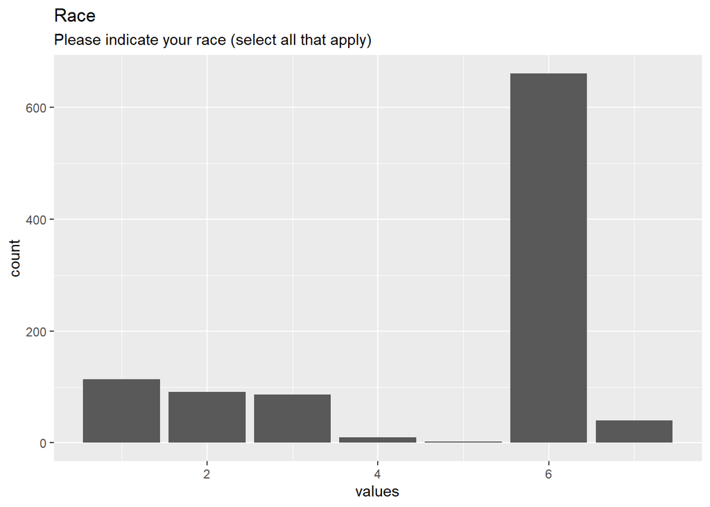

Distribution of values for Race

36 missing values.

#### Summary statistics

| name | label | data_type | n_missing | complete_rate | min | median | max | mean | sd | hist |
| --- | --- | --- | --- | --- | --- | --- | --- | --- | --- | --- |
| Race | Please indicate your race (select all that apply) | numeric | 36 | 0.9653513 | 1 | 6 | 7 | 4.829511 | 1.944296 | ▂▁▁▁▇ |

### Degree

Please indicate the highest degree or level of education that you have completed.

#### Distribution

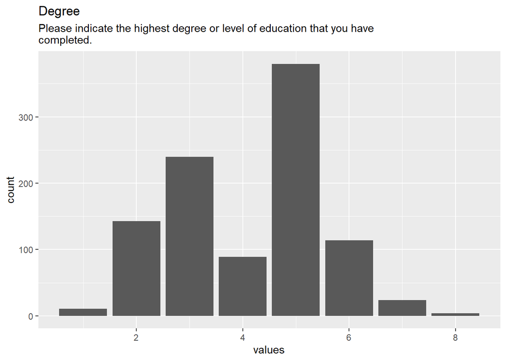

Distribution of values for Degree

34 missing values.

#### Summary statistics

| name | label | data_type | n_missing | complete_rate | min | median | max | mean | sd | hist |
| --- | --- | --- | --- | --- | --- | --- | --- | --- | --- | --- |
| Degree | Please indicate the highest degree or level of education that you have completed. | numeric | 34 | 0.9672762 | 1 | 5 | 8 | 4.136318 | 1.414328 | ▂▅▇▂▁ |

### Income

What is your household income?

#### Distribution

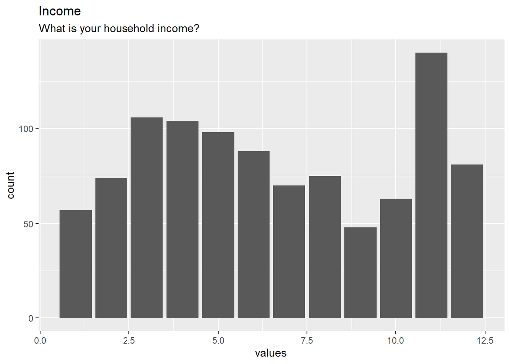

Distribution of values for Income

35 missing values.

#### Summary statistics

| name | label | data_type | n_missing | complete_rate | min | median | max | mean | sd | hist |
| --- | --- | --- | --- | --- | --- | --- | --- | --- | --- | --- |
| Income | What is your household income? | numeric | 35 | 0.9663138 | 1 | 6 | 12 | 6.594621 | 3.451416 | ▇▆▅▃▇ |

### Religion

What is your present religion, if any?

#### Distribution

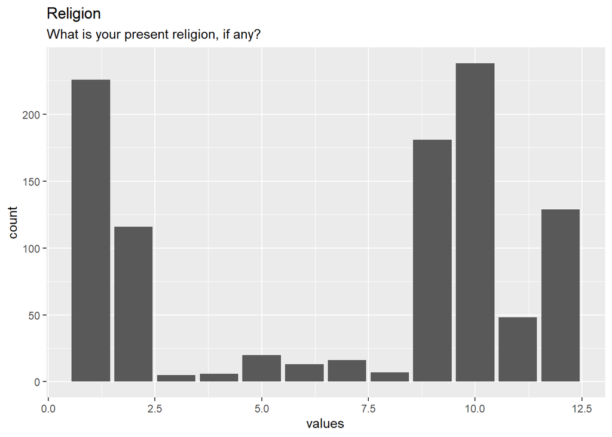

Distribution of values for Religion

34 missing values.

#### Summary statistics

| name | label | data_type | n_missing | complete_rate | min | median | max | mean | sd | hist |
| --- | --- | --- | --- | --- | --- | --- | --- | --- | --- | --- |
| Religion | What is your present religion, if any? | numeric | 34 | 0.9672762 | 1 | 9 | 12 | 6.893532 | 4.247991 | ▇▁▁▃▇ |

### Scale: DGS

#### Overview

**Missing**: 39.

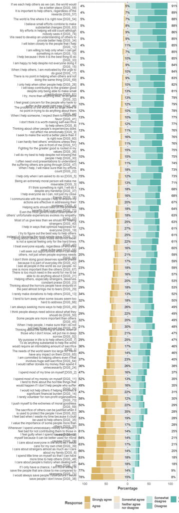

Likert plot of scale DGS items

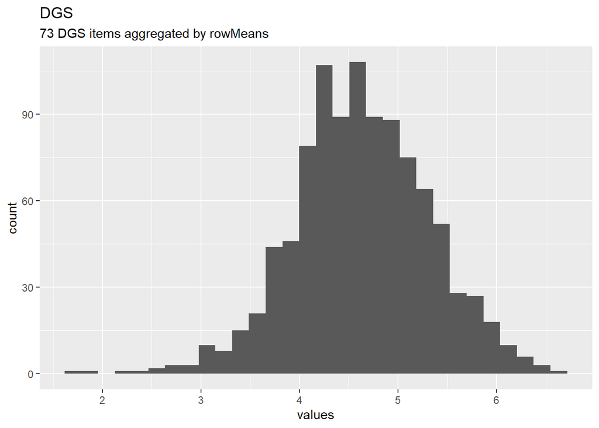

Distribution of scale DGS

#### Reliability details

```
## No viewer found, probably documenting or testing
```

##### Scale structure

###### Information about this scale

| Dataframe: | res$dat |
| --- | --- |
| Items: | DGS_1, DGS_2, DGS_3, DGS_4, DGS_5, DGS_6, DGS_7, DGS_8, DGS_9, DGS_10, DGS_11, DGS_12, DGS_13, DGS_14, DGS_15, DGS_16, DGS_17, DGS_18, DGS_19, DGS_20, DGS_21, DGS_22, DGS_23, DGS_24, DGS_25, DGS_26, D… |
| Observations: | 1000 |
| Positive correlations: | 2389 |
| Number of correlations: | 2628 |
| Percentage positive correlations: | 91 |

###### Estimates assuming interval level

| Omega (total): | 0.96 |
| --- | --- |
| Omega (hierarchical): | 0.50 |
| Revelle’s Omega (total): | 0.96 |
| Greatest Lower Bound (GLB): | 0.96 |
| Coefficient H: | 0.97 |
| Coefficient Alpha: | 0.95 |

(Estimates assuming ordinal level not computed, as the polychoric correlation matrix has missing values.)

Note: the normal point estimate and confidence interval for omega are based on the procedure suggested by Dunn, Baguley & Brunsden (2013) using the MBESS function ci.reliability, whereas the psych package point estimate was suggested in Revelle & Zinbarg (2008). See the help (‘?ufs::scaleStructure’) for more information.

###### Eigen values

19.213, 6.785, 4.324, 2.465, 1.931, 1.598, 1.484, 1.312, 1.156, 1.133, 1.03, 0.975, 0.961, 0.885, 0.88, 0.829, 0.814, 0.784, 0.77, 0.737, 0.723, 0.713, 0.682, 0.668, 0.65, 0.641, 0.621, 0.612, 0.599, 0.586, 0.579, 0.554, 0.553, 0.534, 0.523, 0.518, 0.51, 0.498, 0.49, 0.475, 0.47, 0.462, 0.449, 0.442, 0.433, 0.413, 0.41, 0.4, 0.391, 0.381, 0.38, 0.365, 0.363, 0.362, 0.35, 0.345, 0.338, 0.333, 0.327, 0.321, 0.313, 0.305, 0.301, 0.288, 0.283, 0.274, 0.272, 0.265, 0.252, 0.249, 0.238, 0.222 & 0.209

###### Factor analysis (reproducing only shared variance)

|  | ML7 | ML1 | ML4 | ML6 | ML8 | ML2 | ML5 | ML3 | ML9 | ML11 | ML10 |
| --- | --- | --- | --- | --- | --- | --- | --- | --- | --- | --- | --- |
| DGS_1 | -0.031 | 0.148 | -0.038 | 0.467 | -0.156 | -0.143 | -0.006 | 0.131 | 0.062 | -0.127 | -0.034 |
| DGS_2 | -0.041 | -0.043 | 0.027 | 0.034 | 0.050 | -0.004 | 0.054 | 0.854 | -0.042 | -0.067 | 0.008 |
| DGS_3 | 0.348 | 0.097 | -0.073 | 0.206 | -0.116 | -0.007 | 0.214 | 0.064 | -0.229 | 0.221 | -0.060 |
| DGS_4 | -0.034 | 0.062 | -0.051 | 0.005 | 0.608 | 0.073 | -0.019 | 0.053 | -0.027 | 0.000 | -0.029 |
| DGS_5 | 0.517 | 0.204 | 0.056 | 0.087 | 0.035 | -0.045 | -0.078 | 0.147 | 0.069 | 0.030 | -0.095 |
| DGS_6 | -0.086 | 0.087 | 0.234 | 0.019 | 0.069 | 0.086 | 0.149 | -0.001 | 0.514 | 0.058 | 0.182 |
| DGS_7 | -0.008 | 0.345 | 0.082 | 0.105 | 0.035 | 0.231 | 0.108 | 0.079 | -0.003 | 0.224 | 0.026 |
| DGS_8 | 0.315 | 0.148 | -0.061 | 0.179 | 0.180 | 0.147 | 0.101 | 0.060 | -0.024 | -0.092 | -0.022 |
| DGS_9 | 0.230 | 0.117 | 0.501 | 0.091 | 0.001 | -0.049 | 0.088 | 0.053 | -0.108 | -0.103 | -0.373 |
| DGS_10 | 0.795 | 0.000 | 0.017 | 0.083 | 0.003 | 0.029 | 0.013 | 0.030 | -0.053 | 0.013 | 0.021 |
| DGS_11 | 0.069 | -0.009 | -0.008 | -0.022 | -0.049 | 0.057 | 0.024 | 0.735 | -0.043 | 0.074 | 0.008 |
| DGS_12 | 0.101 | -0.027 | 0.123 | 0.073 | 0.562 | -0.030 | 0.063 | 0.058 | -0.043 | 0.043 | 0.093 |
| DGS_13 | 0.090 | 0.382 | 0.064 | 0.171 | -0.087 | 0.081 | -0.061 | 0.270 | 0.084 | -0.048 | -0.076 |
| DGS_14 | 0.189 | 0.083 | -0.081 | 0.200 | 0.078 | 0.227 | 0.052 | 0.145 | 0.212 | 0.092 | -0.146 |
| DGS_15 | 0.296 | 0.236 | 0.075 | 0.114 | 0.195 | -0.018 | -0.005 | 0.036 | 0.030 | -0.060 | 0.337 |
| DGS_16 | 0.177 | 0.011 | -0.179 | -0.028 | -0.341 | -0.048 | 0.122 | -0.067 | 0.058 | 0.135 | -0.004 |
| DGS_17 | 0.053 | 0.317 | 0.052 | 0.083 | 0.266 | 0.126 | 0.153 | -0.015 | -0.214 | -0.002 | 0.044 |
| DGS_18 | 0.083 | 0.429 | 0.080 | 0.080 | 0.108 | 0.053 | 0.121 | 0.003 | 0.196 | 0.045 | 0.155 |
| DGS_19 | -0.005 | 0.115 | 0.146 | 0.132 | 0.334 | 0.023 | 0.022 | 0.022 | 0.074 | 0.197 | 0.123 |
| DGS_20 | -0.030 | -0.028 | 0.338 | 0.044 | 0.100 | 0.365 | -0.079 | -0.081 | 0.069 | 0.097 | 0.061 |
| DGS_21 | 0.025 | 0.014 | 0.001 | 0.834 | -0.050 | -0.018 | 0.012 | 0.024 | -0.012 | 0.035 | -0.016 |
| DGS_22 | -0.118 | 0.185 | -0.036 | -0.001 | 0.493 | -0.049 | 0.032 | -0.021 | -0.075 | 0.086 | -0.039 |
| DGS_23 | 0.288 | 0.086 | -0.038 | -0.038 | -0.220 | -0.186 | 0.027 | 0.216 | 0.077 | -0.122 | 0.113 |
| DGS_24 | 0.032 | 0.268 | 0.087 | -0.004 | -0.038 | 0.399 | 0.016 | 0.135 | 0.092 | -0.087 | 0.127 |
| DGS_25 | 0.007 | 0.238 | 0.174 | 0.142 | 0.086 | 0.066 | 0.064 | -0.042 | 0.219 | 0.080 | 0.194 |
| DGS_26 | 0.547 | -0.035 | 0.070 | 0.135 | 0.044 | -0.060 | 0.034 | 0.125 | -0.022 | -0.056 | 0.028 |
| DGS_27 | -0.043 | 0.076 | 0.569 | 0.035 | 0.127 | -0.063 | 0.133 | 0.036 | 0.022 | 0.056 | 0.003 |
| DGS_28 | 0.008 | -0.054 | 0.002 | -0.003 | -0.002 | 0.817 | 0.013 | 0.035 | 0.021 | 0.021 | -0.042 |
| DGS_29 | -0.022 | 0.003 | 0.775 | -0.009 | -0.079 | 0.086 | 0.044 | 0.078 | -0.005 | -0.003 | 0.013 |
| DGS_30 | 0.185 | 0.376 | 0.158 | 0.097 | 0.025 | 0.020 | 0.119 | -0.042 | 0.032 | 0.055 | 0.197 |
| DGS_32 | 0.055 | 0.369 | 0.102 | 0.006 | 0.169 | 0.019 | 0.105 | 0.111 | -0.118 | 0.217 | -0.014 |
| DGS_33 | 0.213 | 0.326 | 0.034 | 0.059 | 0.229 | 0.034 | 0.142 | -0.026 | -0.090 | 0.027 | 0.159 |
| DGS_34 | 0.039 | 0.141 | 0.129 | -0.025 | 0.333 | -0.002 | 0.113 | -0.083 | -0.172 | -0.150 | 0.148 |
| DGS_35 | 0.003 | 0.011 | 0.128 | -0.014 | -0.018 | 0.687 | -0.027 | 0.029 | 0.005 | 0.053 | 0.003 |
| DGS_36 | -0.032 | 0.449 | 0.130 | 0.092 | 0.099 | 0.065 | 0.195 | 0.007 | -0.160 | 0.017 | -0.013 |
| DGS_37 | 0.174 | 0.108 | 0.053 | 0.017 | 0.271 | 0.097 | -0.038 | 0.068 | 0.125 | 0.164 | 0.137 |
| DGS_38 | 0.001 | 0.023 | -0.033 | 0.106 | -0.146 | 0.143 | 0.203 | -0.001 | 0.522 | -0.068 | -0.141 |
| DGS_39 | -0.091 | -0.020 | 0.157 | 0.003 | 0.092 | 0.122 | 0.280 | 0.015 | 0.434 | 0.176 | 0.174 |
| DGS_40 | 0.014 | 0.083 | 0.075 | 0.028 | 0.061 | 0.253 | 0.096 | -0.075 | -0.135 | -0.215 | 0.162 |
| DGS_41 | 0.669 | -0.035 | 0.058 | 0.031 | -0.073 | -0.075 | 0.081 | 0.054 | 0.008 | 0.036 | 0.046 |
| DGS_42 | 0.271 | 0.139 | -0.012 | -0.130 | -0.087 | -0.039 | 0.046 | 0.086 | 0.054 | 0.056 | 0.302 |
| DGS_43 | -0.091 | 0.203 | 0.057 | -0.083 | 0.098 | 0.023 | 0.076 | 0.022 | -0.027 | -0.285 | 0.161 |
| DGS_44 | 0.185 | -0.030 | 0.009 | 0.580 | 0.072 | 0.053 | 0.135 | -0.044 | -0.107 | -0.206 | 0.029 |
| DGS_45 | 0.059 | 0.011 | -0.014 | 0.031 | -0.060 | -0.001 | 0.677 | 0.099 | 0.034 | -0.051 | -0.091 |
| DGS_46 | 0.121 | 0.155 | 0.450 | 0.040 | 0.104 | 0.086 | 0.154 | -0.056 | -0.060 | -0.034 | 0.036 |
| DGS_47 | 0.415 | -0.001 | 0.027 | 0.024 | 0.216 | -0.226 | 0.024 | 0.095 | 0.117 | -0.180 | -0.120 |
| DGS_48 | -0.091 | 0.007 | 0.041 | -0.046 | 0.024 | 0.391 | -0.050 | 0.418 | 0.049 | 0.152 | 0.091 |
| DGS_49 | 0.029 | 0.357 | 0.178 | 0.075 | 0.144 | 0.105 | -0.047 | 0.073 | 0.111 | 0.266 | 0.040 |
| DGS_50 | 0.190 | 0.115 | 0.010 | 0.051 | -0.242 | -0.190 | -0.032 | 0.137 | 0.072 | -0.336 | 0.048 |
| DGS_51 | 0.250 | 0.071 | 0.292 | 0.100 | 0.232 | -0.111 | 0.010 | 0.067 | 0.118 | -0.156 | -0.296 |
| DGS_52 | 0.000 | -0.045 | 0.790 | -0.065 | -0.010 | 0.097 | -0.049 | -0.002 | 0.057 | 0.032 | 0.026 |
| DGS_54 | 0.414 | -0.091 | 0.137 | -0.033 | 0.103 | 0.000 | 0.073 | -0.039 | -0.178 | -0.195 | -0.130 |
| DGS_55 | 0.141 | -0.008 | 0.013 | -0.047 | 0.141 | -0.054 | 0.339 | 0.072 | 0.091 | 0.320 | 0.158 |
| DGS_56 | 0.035 | 0.518 | 0.059 | 0.012 | 0.120 | 0.113 | 0.004 | 0.097 | 0.114 | 0.076 | 0.029 |
| DGS_57 | 0.329 | 0.202 | 0.068 | 0.052 | 0.109 | 0.114 | 0.196 | -0.043 | -0.171 | -0.021 | 0.208 |
| DGS_58 | 0.166 | 0.062 | 0.108 | 0.145 | 0.227 | 0.095 | 0.156 | -0.024 | -0.245 | -0.124 | 0.223 |
| DGS_59 | -0.077 | 0.176 | 0.111 | 0.064 | 0.050 | 0.161 | 0.054 | 0.126 | 0.000 | 0.437 | -0.027 |
| DGS_60 | -0.133 | 0.528 | 0.119 | 0.143 | 0.183 | 0.050 | 0.109 | -0.026 | -0.080 | -0.072 | -0.012 |
| DGS_61 | 0.088 | 0.439 | 0.068 | 0.150 | 0.091 | 0.037 | 0.092 | 0.044 | -0.075 | -0.061 | 0.219 |
| DGS_62 | 0.082 | 0.025 | -0.041 | 0.040 | -0.104 | 0.012 | 0.258 | 0.021 | 0.181 | -0.279 | -0.078 |
| DGS_63 | -0.004 | 0.111 | 0.113 | 0.410 | 0.151 | -0.033 | 0.010 | -0.012 | -0.148 | -0.046 | 0.308 |
| DGS_64 | 0.086 | 0.148 | 0.046 | 0.073 | 0.221 | 0.315 | -0.021 | 0.087 | 0.119 | 0.248 | 0.050 |
| DGS_65 | -0.059 | -0.016 | -0.037 | 0.798 | 0.031 | -0.023 | -0.069 | 0.057 | 0.122 | 0.086 | -0.011 |
| DGS_66 | 0.243 | 0.012 | -0.062 | 0.218 | 0.207 | -0.036 | -0.016 | 0.254 | 0.129 | 0.086 | -0.137 |
| DGS_67 | -0.073 | -0.005 | 0.116 | -0.020 | 0.063 | 0.017 | 0.658 | 0.039 | 0.057 | 0.071 | 0.115 |
| DGS_68 | -0.029 | 0.056 | 0.028 | -0.057 | -0.005 | 0.762 | 0.010 | 0.024 | 0.035 | -0.085 | -0.005 |
| DGS_69 | 0.400 | -0.032 | 0.029 | 0.331 | 0.121 | 0.001 | 0.075 | 0.030 | -0.070 | -0.178 | 0.083 |
| DGS_70 | 0.020 | 0.034 | 0.023 | -0.039 | -0.061 | -0.046 | 0.529 | 0.111 | 0.264 | -0.043 | -0.106 |
| DGS_71 | 0.037 | -0.039 | -0.067 | 0.102 | -0.123 | 0.189 | 0.153 | 0.014 | 0.531 | -0.018 | -0.126 |
| DGS_72 | 0.490 | 0.022 | -0.035 | -0.038 | 0.010 | 0.012 | 0.153 | 0.037 | 0.067 | -0.238 | -0.056 |
| DGS_73 | -0.051 | 0.427 | -0.012 | 0.113 | -0.069 | 0.010 | -0.065 | 0.190 | 0.159 | 0.022 | -0.190 |
| DGS_74 | 0.271 | 0.057 | 0.054 | 0.206 | 0.137 | -0.059 | 0.064 | -0.025 | -0.136 | -0.035 | 0.304 |
| DGS_75 | 0.113 | 0.260 | -0.004 | -0.008 | 0.382 | 0.069 | -0.049 | 0.047 | 0.101 | 0.102 | 0.064 |

###### Component analysis (reproducing full covariance matrix)

|  | TC2 | TC1 | TC8 | TC11 | TC4 | TC10 | TC9 | TC3 | TC5 | TC6 | TC7 |
| --- | --- | --- | --- | --- | --- | --- | --- | --- | --- | --- | --- |
| DGS_1 | -0.092 | 0.132 | -0.155 | 0.597 | -0.025 | -0.165 | -0.003 | 0.072 | 0.129 | 0.055 | -0.193 |
| DGS_2 | 0.094 | 0.027 | 0.150 | 0.082 | 0.013 | 0.067 | 0.162 | -0.054 | 0.695 | 0.094 | -0.030 |
| DGS_3 | 0.256 | 0.124 | -0.025 | 0.260 | -0.095 | -0.153 | 0.310 | -0.277 | 0.231 | -0.059 | 0.184 |
| DGS_4 | 0.062 | 0.068 | 0.017 | -0.036 | -0.048 | 0.712 | -0.018 | -0.026 | 0.043 | -0.030 | -0.025 |
| DGS_5 | 0.471 | 0.207 | -0.080 | 0.137 | 0.131 | 0.026 | -0.095 | 0.068 | 0.204 | 0.139 | 0.046 |
| DGS_6 | -0.176 | 0.092 | 0.134 | 0.061 | 0.245 | 0.097 | 0.213 | 0.461 | -0.155 | 0.131 | 0.121 |
| DGS_7 | -0.072 | 0.431 | 0.247 | 0.097 | 0.111 | 0.032 | 0.101 | 0.000 | 0.087 | 0.048 | 0.167 |
| DGS_8 | 0.460 | 0.171 | 0.199 | 0.215 | -0.090 | 0.157 | 0.093 | 0.026 | 0.016 | -0.077 | -0.053 |
| DGS_9 | 0.395 | 0.155 | -0.104 | 0.022 | 0.565 | -0.055 | 0.040 | -0.010 | 0.151 | -0.141 | -0.146 |
| DGS_10 | 0.691 | 0.030 | 0.005 | 0.149 | 0.032 | -0.029 | 0.030 | -0.061 | 0.070 | 0.157 | 0.050 |
| DGS_11 | 0.095 | 0.036 | 0.200 | 0.026 | -0.029 | 0.000 | 0.145 | -0.077 | 0.699 | 0.096 | 0.071 |
| DGS_12 | 0.169 | 0.000 | -0.032 | 0.084 | 0.122 | 0.550 | 0.103 | -0.107 | -0.041 | 0.070 | 0.110 |
| DGS_13 | 0.058 | 0.406 | 0.114 | 0.242 | 0.112 | -0.068 | -0.039 | 0.068 | 0.321 | 0.018 | -0.109 |
| DGS_14 | 0.281 | 0.120 | 0.280 | 0.174 | -0.133 | 0.149 | 0.000 | 0.369 | 0.191 | -0.029 | 0.042 |
| DGS_15 | 0.234 | 0.225 | 0.061 | 0.228 | 0.056 | 0.183 | 0.041 | -0.087 | -0.166 | 0.276 | 0.043 |
| DGS_16 | 0.242 | 0.314 | -0.088 | -0.199 | -0.249 | -0.545 | 0.021 | 0.176 | -0.126 | 0.057 | 0.248 |
| DGS_17 | 0.152 | 0.375 | 0.126 | 0.078 | 0.058 | 0.244 | 0.134 | -0.201 | -0.085 | -0.044 | -0.007 |
| DGS_18 | -0.008 | 0.430 | 0.070 | 0.156 | 0.111 | 0.123 | 0.153 | 0.138 | -0.105 | 0.148 | 0.056 |
| DGS_19 | -0.091 | 0.111 | 0.018 | 0.206 | 0.180 | 0.349 | 0.100 | -0.016 | -0.035 | 0.049 | 0.247 |
| DGS_20 | -0.100 | -0.107 | 0.403 | 0.076 | 0.424 | 0.115 | -0.109 | 0.070 | -0.101 | 0.081 | 0.113 |
| DGS_21 | 0.081 | 0.062 | -0.038 | 0.789 | -0.018 | -0.036 | 0.001 | 0.051 | 0.042 | -0.013 | 0.038 |
| DGS_22 | -0.080 | 0.185 | -0.160 | -0.043 | -0.024 | 0.627 | 0.064 | -0.096 | 0.005 | -0.093 | 0.051 |
| DGS_23 | 0.073 | -0.071 | -0.198 | 0.037 | 0.034 | -0.162 | -0.040 | 0.026 | 0.201 | 0.667 | -0.169 |
| DGS_24 | -0.055 | 0.243 | 0.480 | 0.056 | 0.104 | 0.000 | 0.074 | 0.040 | 0.102 | 0.122 | -0.122 |
| DGS_25 | -0.100 | 0.232 | 0.103 | 0.231 | 0.195 | 0.093 | 0.105 | 0.159 | -0.169 | 0.133 | 0.125 |
| DGS_26 | 0.573 | -0.027 | -0.049 | 0.191 | 0.091 | -0.011 | 0.060 | -0.046 | 0.099 | 0.109 | 0.047 |
| DGS_27 | -0.047 | 0.085 | -0.061 | 0.038 | 0.634 | 0.097 | 0.175 | -0.037 | -0.017 | 0.056 | 0.082 |
| DGS_28 | -0.022 | -0.041 | 0.765 | -0.050 | 0.080 | 0.010 | -0.002 | 0.111 | 0.126 | -0.031 | 0.009 |
| DGS_29 | 0.021 | 0.031 | 0.183 | -0.038 | 0.721 | -0.056 | 0.101 | -0.026 | 0.032 | 0.028 | 0.004 |
| DGS_30 | 0.105 | 0.384 | 0.059 | 0.151 | 0.158 | 0.025 | 0.146 | -0.040 | -0.146 | 0.187 | 0.078 |
| DGS_32 | 0.030 | 0.481 | -0.012 | -0.033 | 0.131 | 0.177 | 0.085 | -0.128 | 0.127 | 0.076 | 0.158 |
| DGS_33 | 0.229 | 0.388 | 0.070 | 0.095 | 0.016 | 0.187 | 0.145 | -0.137 | -0.150 | 0.099 | 0.054 |
| DGS_34 | 0.074 | 0.124 | 0.020 | 0.013 | 0.122 | 0.304 | 0.163 | -0.291 | -0.197 | 0.063 | -0.143 |
| DGS_35 | -0.013 | 0.040 | 0.688 | -0.035 | 0.193 | -0.046 | -0.028 | 0.056 | 0.073 | -0.055 | 0.084 |
| DGS_36 | 0.034 | 0.513 | 0.058 | 0.080 | 0.171 | 0.069 | 0.159 | -0.144 | -0.037 | -0.034 | -0.026 |
| DGS_37 | 0.183 | 0.130 | 0.154 | 0.001 | -0.002 | 0.373 | -0.081 | 0.158 | -0.032 | 0.209 | 0.198 |
| DGS_38 | 0.044 | 0.019 | 0.098 | 0.087 | -0.004 | -0.107 | 0.170 | 0.719 | -0.041 | -0.050 | -0.056 |
| DGS_39 | -0.206 | 0.018 | 0.161 | 0.017 | 0.142 | 0.119 | 0.371 | 0.376 | -0.084 | 0.105 | 0.213 |
| DGS_40 | 0.135 | 0.047 | 0.483 | 0.060 | -0.067 | 0.049 | 0.129 | -0.163 | -0.236 | -0.012 | -0.300 |
| DGS_41 | 0.621 | 0.001 | -0.062 | 0.070 | 0.056 | -0.129 | 0.083 | -0.001 | 0.043 | 0.191 | 0.112 |
| DGS_42 | -0.010 | -0.033 | 0.039 | -0.072 | -0.028 | 0.012 | -0.003 | -0.052 | 0.002 | 0.812 | 0.012 |
| DGS_43 | -0.047 | 0.301 | 0.147 | -0.163 | -0.091 | 0.194 | 0.085 | -0.042 | -0.159 | 0.169 | -0.522 |
| DGS_44 | 0.300 | -0.007 | 0.025 | 0.591 | 0.016 | 0.015 | 0.121 | -0.063 | -0.097 | -0.030 | -0.137 |
| DGS_45 | 0.060 | -0.035 | -0.048 | 0.030 | 0.024 | -0.061 | 0.776 | 0.043 | 0.158 | -0.021 | -0.102 |
| DGS_46 | 0.181 | 0.152 | 0.133 | 0.060 | 0.471 | 0.061 | 0.156 | -0.070 | -0.143 | 0.022 | 0.000 |
| DGS_47 | 0.517 | -0.041 | -0.303 | 0.016 | 0.084 | 0.233 | -0.014 | 0.154 | 0.082 | 0.141 | -0.132 |
| DGS_48 | -0.146 | 0.036 | 0.519 | -0.032 | 0.015 | 0.093 | 0.020 | 0.033 | 0.401 | 0.118 | 0.122 |
| DGS_49 | -0.078 | 0.379 | 0.128 | 0.111 | 0.214 | 0.178 | -0.023 | 0.067 | 0.070 | 0.085 | 0.228 |
| DGS_50 | 0.048 | -0.010 | -0.183 | 0.179 | 0.048 | -0.209 | 0.002 | 0.003 | 0.122 | 0.301 | -0.447 |
| DGS_51 | 0.435 | 0.105 | -0.200 | 0.062 | 0.404 | 0.164 | -0.041 | 0.195 | 0.092 | -0.110 | -0.115 |
| DGS_52 | 0.013 | 0.008 | 0.177 | -0.115 | 0.741 | 0.001 | 0.000 | 0.028 | -0.054 | 0.050 | 0.039 |
| DGS_54 | 0.603 | -0.126 | -0.027 | -0.071 | 0.200 | 0.032 | 0.050 | -0.158 | -0.005 | -0.087 | -0.130 |
| DGS_55 | 0.095 | 0.095 | -0.050 | -0.108 | -0.049 | 0.127 | 0.416 | 0.055 | 0.000 | 0.176 | 0.431 |
| DGS_56 | -0.046 | 0.521 | 0.103 | 0.064 | 0.130 | 0.148 | 0.004 | 0.080 | 0.070 | 0.122 | 0.039 |
| DGS_57 | 0.359 | 0.233 | 0.189 | 0.093 | 0.022 | 0.072 | 0.194 | -0.193 | -0.176 | 0.125 | 0.030 |
| DGS_58 | 0.243 | 0.093 | 0.163 | 0.218 | 0.075 | 0.141 | 0.214 | -0.335 | -0.171 | -0.003 | -0.024 |
| DGS_59 | -0.194 | 0.236 | 0.178 | 0.029 | 0.102 | 0.137 | 0.062 | 0.018 | 0.229 | 0.045 | 0.338 |
| DGS_60 | -0.068 | 0.513 | 0.029 | 0.159 | 0.173 | 0.199 | 0.071 | -0.078 | -0.075 | -0.003 | -0.121 |
| DGS_61 | 0.094 | 0.441 | 0.084 | 0.226 | 0.070 | 0.088 | 0.111 | -0.132 | -0.105 | 0.127 | -0.008 |
| DGS_62 | 0.120 | -0.029 | -0.014 | 0.007 | -0.061 | -0.030 | 0.291 | 0.307 | -0.018 | 0.080 | -0.420 |
| DGS_63 | -0.005 | 0.071 | 0.056 | 0.533 | 0.075 | 0.132 | 0.049 | -0.246 | -0.200 | 0.132 | 0.055 |
| DGS_64 | 0.022 | 0.169 | 0.353 | 0.090 | 0.049 | 0.280 | -0.019 | 0.135 | 0.091 | 0.079 | 0.228 |
| DGS_65 | -0.085 | -0.013 | -0.034 | 0.826 | -0.051 | 0.077 | -0.053 | 0.152 | 0.085 | 0.001 | 0.064 |
| DGS_66 | 0.290 | 0.032 | -0.067 | 0.235 | -0.060 | 0.264 | 0.004 | 0.172 | 0.337 | 0.001 | 0.105 |
| DGS_67 | -0.063 | 0.020 | 0.041 | -0.023 | 0.096 | 0.045 | 0.754 | 0.026 | -0.051 | 0.009 | 0.095 |
| DGS_68 | -0.020 | 0.056 | 0.731 | -0.083 | 0.120 | -0.028 | -0.021 | 0.111 | 0.049 | -0.013 | -0.051 |
| DGS_69 | 0.481 | -0.024 | 0.006 | 0.397 | 0.038 | 0.041 | 0.100 | -0.093 | -0.044 | 0.040 | -0.044 |
| DGS_70 | -0.057 | -0.016 | -0.128 | -0.045 | 0.073 | -0.014 | 0.653 | 0.274 | 0.176 | 0.045 | -0.113 |
| DGS_71 | 0.059 | -0.038 | 0.147 | 0.094 | -0.032 | -0.098 | 0.124 | 0.718 | -0.019 | -0.047 | 0.023 |
| DGS_72 | 0.565 | -0.030 | -0.005 | -0.042 | -0.032 | 0.032 | 0.134 | 0.137 | 0.018 | 0.144 | -0.240 |
| DGS_73 | -0.105 | 0.594 | -0.073 | 0.090 | 0.038 | -0.030 | -0.072 | 0.198 | 0.315 | -0.113 | -0.126 |
| DGS_74 | 0.245 | 0.037 | 0.029 | 0.307 | -0.020 | 0.122 | 0.096 | -0.229 | -0.188 | 0.229 | 0.044 |
| DGS_75 | 0.071 | 0.248 | 0.060 | 0.013 | -0.005 | 0.486 | -0.050 | 0.082 | 0.010 | 0.142 | 0.078 |

###### Item descriptives

|  | mean | median | var | sd | IQR | se | min | q1 | q3 | max | skew | kurt | dip | n | NA | valid |
| --- | --- | --- | --- | --- | --- | --- | --- | --- | --- | --- | --- | --- | --- | --- | --- | --- |
| DGS_1 | 4.211 | 4 | 2.8553 | 1.6898 | 3 | 0.0534 | 1 | 3 | 6 | 7 | -0.1177 | -0.9064 | 0.092 | 1000 | 0 | 1000 |
| DGS_2 | 3.885 | 4 | 2.7405 | 1.6555 | 2 | 0.0523 | 1 | 3 | 6 | 7 | 0.2222 | -0.9323 | 0.0905 | 1000 | 0 | 1000 |
| DGS_3 | 5.26 | 6 | 2.619 | 1.6183 | 3 | 0.0512 | 1 | 4 | 7 | 7 | -0.887 | -0.048 | 0.1255 | 1000 | 0 | 1000 |
| DGS_4 | 4.901 | 5 | 1.7269 | 1.3141 | 2 | 0.0416 | 1 | 4 | 6 | 7 | -0.6893 | 0.3852 | 0.1345 | 1000 | 0 | 1000 |
| DGS_5 | 5.194 | 5 | 2.0744 | 1.4403 | 2 | 0.0455 | 1 | 3 | 6 | 7 | -0.739 | -0.0041 | 0.129 | 1000 | 0 | 1000 |
| DGS_6 | 3.072 | 3 | 2.5093 | 1.5841 | 2 | 0.0501 | 1 | 2 | 5 | 7 | 0.5612 | -0.4365 | 0.1195 | 1000 | 0 | 1000 |
| DGS_7 | 4.282 | 4 | 2.4309 | 1.5591 | 2 | 0.0493 | 1 | 3 | 5 | 7 | -0.2559 | -0.5125 | 0.1205 | 1000 | 0 | 1000 |
| DGS_8 | 5.34 | 6 | 1.8683 | 1.3668 | 1 | 0.0432 | 1 | 5 | 7 | 7 | -0.8653 | 0.4526 | 0.1225 | 1000 | 0 | 1000 |
| DGS_9 | 5.284 | 6 | 2.1635 | 1.4709 | 1 | 0.0465 | 1 | 4 | 7 | 7 | -0.9501 | 0.4285 | 0.117 | 1000 | 0 | 1000 |
| DGS_10 | 5.822 | 6 | 1.8362 | 1.355 | 2 | 0.0429 | 1 | 5 | 7 | 7 | -1.3436 | 1.452 | 0.1515 | 1000 | 0 | 1000 |
| DGS_11 | 3.72 | 3 | 3.2128 | 1.7924 | 3 | 0.0567 | 1 | 2 | 5 | 7 | 0.2919 | -1.0316 | 0.107 | 1000 | 0 | 1000 |
| DGS_12 | 5.528 | 6 | 1.1464 | 1.0707 | 1 | 0.0339 | 1 | 5 | 7 | 7 | -0.8035 | 1.1897 | 0.1495 | 1000 | 0 | 1000 |
| DGS_13 | 4.348 | 5 | 2.9739 | 1.7245 | 3 | 0.0545 | 1 | 3 | 6 | 7 | -0.2522 | -0.966 | 0.101 | 1000 | 0 | 1000 |
| DGS_14 | 3.727 | 4 | 2.509 | 1.584 | 2 | 0.0501 | 1 | 2 | 5 | 7 | 0.2136 | -0.6455 | 0.109 | 1000 | 0 | 1000 |
| DGS_15 | 5.481 | 6 | 1.2969 | 1.1388 | 1 | 0.036 | 1 | 5 | 7 | 7 | -0.9208 | 1.3469 | 0.1505 | 1000 | 0 | 1000 |
| DGS_16 | 3.228 | 3 | 2.1662 | 1.4718 | 2 | 0.0465 | 1 | 2 | 4 | 7 | 0.6594 | -0.0657 | 0.1305 | 1000 | 0 | 1000 |
| DGS_17 | 5.455 | 6 | 1.3393 | 1.1573 | 1 | 0.0366 | 1 | 5 | 7 | 7 | -0.9988 | 1.7458 | 0.1575 | 1000 | 0 | 1000 |
| DGS_18 | 4.857 | 5 | 1.9665 | 1.4023 | 2 | 0.0443 | 1 | 3 | 6 | 7 | -0.6522 | 0.1152 | 0.12 | 1000 | 0 | 1000 |
| DGS_19 | 4.757 | 5 | 1.4874 | 1.2196 | 2 | 0.0386 | 1 | 4 | 6 | 7 | -0.4497 | 0.3921 | 0.134 | 1000 | 0 | 1000 |
| DGS_20 | 3.656 | 4 | 2.7704 | 1.6645 | 3 | 0.0526 | 1 | 2 | 5 | 7 | 0.152 | -0.9769 | 0.0975 | 1000 | 0 | 1000 |
| DGS_21 | 4.685 | 5 | 2.9147 | 1.7072 | 3 | 0.054 | 1 | 3 | 6 | 7 | -0.4108 | -0.7834 | 0.094 | 1000 | 0 | 1000 |
| DGS_22 | 5.105 | 5 | 1.4694 | 1.2122 | 2 | 0.0383 | 1 | 4 | 6 | 7 | -0.729 | 0.8439 | 0.1475 | 1000 | 0 | 1000 |
| DGS_23 | 4.655 | 5 | 2.9029 | 1.7038 | 3 | 0.0539 | 1 | 3 | 6 | 7 | -0.2889 | -0.9024 | 0.0975 | 1000 | 0 | 1000 |
| DGS_24 | 3.962 | 4 | 2.463 | 1.5694 | 2 | 0.0496 | 1 | 2 | 5 | 7 | -0.113 | -0.593 | 0.1075 | 1000 | 0 | 1000 |
| DGS_25 | 4.436 | 4 | 1.7156 | 1.3098 | 1 | 0.0414 | 1 | 3 | 5 | 7 | -0.2083 | -0.1204 | 0.141 | 1000 | 0 | 1000 |
| DGS_26 | 5.591 | 6 | 1.6434 | 1.2819 | 2 | 0.0405 | 1 | 5 | 7 | 7 | -1.0256 | 0.8813 | 0.1315 | 1000 | 0 | 1000 |
| DGS_27 | 4.69 | 5 | 2.128 | 1.4588 | 2 | 0.0461 | 1 | 3 | 6 | 7 | -0.642 | 0.0889 | 0.106 | 1000 | 0 | 1000 |
| DGS_28 | 3.113 | 3 | 2.6209 | 1.6189 | 2 | 0.0512 | 1 | 2 | 5 | 7 | 0.5683 | -0.5144 | 0.111 | 1000 | 0 | 1000 |
| DGS_29 | 4.398 | 5 | 3.0066 | 1.734 | 3 | 0.0548 | 1 | 3 | 6 | 7 | -0.3543 | -0.8102 | 0.0955 | 1000 | 0 | 1000 |
| DGS_30 | 5.131 | 5 | 1.6235 | 1.2742 | 1 | 0.0403 | 1 | 4 | 6 | 7 | -0.8227 | 0.9558 | 0.14 | 1000 | 0 | 1000 |
| DGS_32 | 5.35 | 6 | 1.6331 | 1.2779 | 1 | 0.0404 | 1 | 5 | 7 | 7 | -0.8689 | 0.792 | 0.14 | 1000 | 0 | 1000 |
| DGS_33 | 5.573 | 6 | 1.316 | 1.1472 | 1 | 0.0363 | 1 | 5 | 7 | 7 | -1.0624 | 1.5791 | 0.1235 | 1000 | 0 | 1000 |
| DGS_34 | 5.583 | 6 | 1.4145 | 1.1893 | 1 | 0.0376 | 1 | 5 | 7 | 7 | -1.1761 | 2.0078 | 0.125 | 1000 | 0 | 1000 |
| DGS_35 | 3.455 | 3 | 2.6226 | 1.6194 | 3 | 0.0512 | 1 | 2 | 5 | 7 | 0.2623 | -0.7401 | 0.1 | 1000 | 0 | 1000 |
| DGS_36 | 5.197 | 5 | 1.6599 | 1.2884 | 1 | 0.0407 | 1 | 4 | 6 | 7 | -0.7873 | 0.7602 | 0.145 | 1000 | 0 | 1000 |
| DGS_37 | 4.876 | 5 | 1.4781 | 1.2158 | 2 | 0.0384 | 1 | 4 | 6 | 7 | -0.5787 | 0.4209 | 0.116 | 1000 | 0 | 1000 |
| DGS_38 | 2.515 | 2 | 1.8616 | 1.3644 | 2 | 0.0431 | 1 | 1 | 3 | 7 | 0.851 | 0.4068 | 0.1375 | 1000 | 0 | 1000 |
| DGS_39 | 3.067 | 3 | 2.7072 | 1.6454 | 2 | 0.052 | 1 | 2 | 5 | 7 | 0.5006 | -0.5786 | 0.105 | 1000 | 0 | 1000 |
| DGS_40 | 4.873 | 5 | 1.8587 | 1.3634 | 2 | 0.0431 | 1 | 4 | 6 | 7 | -0.565 | 0.1937 | 0.1255 | 1000 | 0 | 1000 |
| DGS_41 | 5.446 | 6 | 2.0752 | 1.4405 | 2 | 0.0456 | 1 | 4 | 7 | 7 | -0.8712 | 0.1111 | 0.138 | 1000 | 0 | 1000 |
| DGS_42 | 4.695 | 5 | 2.4504 | 1.5654 | 2 | 0.0495 | 1 | 3 | 6 | 7 | -0.3982 | -0.6355 | 0.1165 | 1000 | 0 | 1000 |
| DGS_43 | 4.857 | 5 | 2.5071 | 1.5834 | 2 | 0.0501 | 1 | 4 | 6 | 7 | -0.6402 | -0.1635 | 0.112 | 1000 | 0 | 1000 |
| DGS_44 | 5.544 | 6 | 2.2283 | 1.4927 | 2 | 0.0472 | 1 | 4 | 7 | 7 | -1.0343 | 0.3726 | 0.15 | 1000 | 0 | 1000 |
| DGS_45 | 4.496 | 4 | 3.3674 | 1.835 | 3 | 0.058 | 1 | 2 | 6 | 7 | -0.2171 | -1.0394 | 0.0975 | 1000 | 0 | 1000 |
| DGS_46 | 5.36 | 6 | 1.8803 | 1.3712 | 1 | 0.0434 | 1 | 5 | 7 | 7 | -0.9287 | 0.7464 | 0.138 | 1000 | 0 | 1000 |
| DGS_47 | 5.355 | 6 | 2.1832 | 1.4776 | 2 | 0.0467 | 1 | 4 | 7 | 7 | -0.8161 | -0.1185 | 0.1245 | 1000 | 0 | 1000 |
| DGS_48 | 3.119 | 3 | 2.3212 | 1.5235 | 2 | 0.0482 | 1 | 2 | 5 | 7 | 0.537 | -0.347 | 0.117 | 1000 | 0 | 1000 |
| DGS_49 | 4.389 | 4 | 2.0497 | 1.4317 | 1 | 0.0453 | 1 | 3 | 5 | 7 | -0.2835 | -0.2565 | 0.13 | 1000 | 0 | 1000 |
| DGS_50 | 4.467 | 4 | 2.3933 | 1.547 | 3 | 0.0489 | 1 | 3 | 6 | 7 | -0.1583 | -0.7311 | 0.101 | 1000 | 0 | 1000 |
| DGS_51 | 5.312 | 6 | 2.2009 | 1.4835 | 1 | 0.0469 | 1 | 4 | 7 | 7 | -0.8516 | 0.0892 | 0.118 | 1000 | 0 | 1000 |
| DGS_52 | 4.216 | 4 | 2.7541 | 1.6595 | 2 | 0.0525 | 1 | 2 | 6 | 7 | -0.2355 | -0.788 | 0.103 | 1000 | 0 | 1000 |
| DGS_54 | 5.983 | 6 | 1.5583 | 1.2483 | 2 | 0.0395 | 1 | 5 | 7 | 7 | -1.4993 | 2.2167 | 0.151 | 1000 | 0 | 1000 |
| DGS_55 | 4.72 | 5 | 2.3359 | 1.5284 | 2 | 0.0483 | 1 | 3 | 6 | 7 | -0.3781 | -0.6761 | 0.118 | 1000 | 0 | 1000 |
| DGS_56 | 4.635 | 5 | 1.9217 | 1.3863 | 2 | 0.0438 | 1 | 4 | 6 | 7 | -0.4707 | -0.0914 | 0.1045 | 1000 | 0 | 1000 |
| DGS_57 | 5.806 | 6 | 1.3177 | 1.1479 | 2 | 0.0363 | 1 | 5 | 7 | 7 | -1.3704 | 2.7768 | 0.1485 | 1000 | 0 | 1000 |
| DGS_58 | 5.973 | 6 | 1.2755 | 1.1294 | 2 | 0.0357 | 1 | 5 | 7 | 7 | -1.5009 | 3.0248 | 0.18 | 1000 | 0 | 1000 |
| DGS_59 | 3.533 | 4 | 2.5615 | 1.6005 | 3 | 0.0506 | 1 | 2 | 5 | 7 | 0.2079 | -0.8067 | 0.106 | 1000 | 0 | 1000 |
| DGS_60 | 5.244 | 5 | 1.6061 | 1.2673 | 1 | 0.0401 | 1 | 4 | 6 | 7 | -0.7377 | 0.7687 | 0.1395 | 1000 | 0 | 1000 |
| DGS_61 | 5.421 | 6 | 1.5033 | 1.2261 | 1 | 0.0388 | 1 | 5 | 7 | 7 | -0.8861 | 1.1713 | 0.1515 | 1000 | 0 | 1000 |
| DGS_62 | 3.887 | 4 | 2.1484 | 1.4657 | 2 | 0.0464 | 1 | 3 | 6 | 7 | 0.0701 | -0.2796 | 0.0945 | 1000 | 0 | 1000 |
| DGS_63 | 5.691 | 6 | 1.3549 | 1.164 | 2 | 0.0368 | 1 | 5 | 7 | 7 | -1.2076 | 2.289 | 0.1295 | 1000 | 0 | 1000 |
| DGS_64 | 4.012 | 4 | 2.2681 | 1.506 | 2 | 0.0476 | 1 | 3 | 5 | 7 | -0.0451 | -0.6147 | 0.117 | 1000 | 0 | 1000 |
| DGS_65 | 4.226 | 4 | 3.072 | 1.7527 | 3 | 0.0554 | 1 | 3 | 6 | 7 | -0.0749 | -0.9836 | 0.093 | 1000 | 0 | 1000 |
| DGS_66 | 4.459 | 5 | 2.4408 | 1.5623 | 3 | 0.0494 | 1 | 3 | 6 | 7 | -0.095 | -0.8903 | 0.103 | 1000 | 0 | 1000 |
| DGS_67 | 4.748 | 5 | 2.6592 | 1.6307 | 2 | 0.0516 | 1 | 3 | 6 | 7 | -0.4311 | -0.6311 | 0.104 | 1000 | 0 | 1000 |
| DGS_68 | 3.194 | 3 | 2.7651 | 1.6629 | 2.5 | 0.0526 | 1 | 2 | 5 | 7 | 0.4505 | -0.7225 | 0.1035 | 1000 | 0 | 1000 |
| DGS_69 | 5.748 | 6 | 1.7883 | 1.3373 | 2 | 0.0423 | 1 | 4 | 7 | 7 | -1.2463 | 1.3158 | 0.1645 | 1000 | 0 | 1000 |
| DGS_70 | 3.572 | 3 | 2.8497 | 1.6881 | 3 | 0.0534 | 1 | 2 | 5 | 7 | 0.4153 | -0.6963 | 0.099 | 1000 | 0 | 1000 |
| DGS_71 | 2.664 | 2 | 1.8049 | 1.3435 | 1 | 0.0425 | 1 | 1 | 3 | 7 | 0.8221 | 0.4683 | 0.134 | 1000 | 0 | 1000 |
| DGS_72 | 5.094 | 5 | 2.4256 | 1.5574 | 2 | 0.0493 | 1 | 4 | 6 | 7 | -0.5518 | -0.5667 | 0.1065 | 1000 | 0 | 1000 |
| DGS_73 | 3.353 | 3 | 3.3798 | 1.8384 | 3 | 0.0581 | 1 | 2 | 5 | 7 | 0.3899 | -1.0044 | 0.092 | 1000 | 0 | 1000 |
| DGS_74 | 5.758 | 6 | 1.5129 | 1.23 | 2 | 0.0389 | 1 | 5 | 7 | 7 | -1.1903 | 1.5055 | 0.158 | 1000 | 0 | 1000 |
| DGS_75 | 4.792 | 5 | 1.6324 | 1.2776 | 2 | 0.0404 | 1 | 4 | 6 | 7 | -0.3595 | -0.0918 | 0.124 | 1000 | 0 | 1000 |

###### Scattermatrix

[figure not shown]

Scatterplot

```
## No viewer found, probably documenting or testing
```

#### Summary statistics

| name | label | data_type | value_labels | n_missing | complete_rate | min | median | max | mean | sd | n_value_labels | hist |
| --- | --- | --- | --- | --- | --- | --- | --- | --- | --- | --- | --- | --- |
| DGS_1 | To do anything substantial to help the world would require an intimidating amount of sacrifice | haven_labelled | 7. Strongly disagree, 6. Disagree, 5. Somewhat disagree, 4. Neither agree nor disagree, 3. Somewhat agree, 2. Agree, 1. Strongly agree | 33 | 0.9682387 | 1 | 4 | 7 | 4.203777 | 1.691426 | 7 | ▂▅▇▇▁▇▆▃ |
| DGS_2 | I spend most of my time on myself | haven_labelled | 7. Strongly disagree, 6. Disagree, 5. Somewhat disagree, 4. Neither agree nor disagree, 3. Somewhat agree, 2. Agree, 1. Strongly agree | 33 | 0.9682387 | 1 | 4 | 7 | 3.885686 | 1.655341 | 7 | ▂▆▇▆▁▆▅▂ |
| DGS_3 | Being an extremely moral person will make me miserable | haven_labelled | 7. Strongly disagree, 6. Disagree, 5. Somewhat disagree, 4. Neither agree nor disagree, 3. Somewhat agree, 2. Agree, 1. Strongly agree | 33 | 0.9682387 | 1 | 6 | 7 | 5.247515 | 1.622408 | 7 | ▁▂▂▃▁▃▇▆ |
| DGS_4 | I communicate with the people I help to ensure my actions are effective in addressing their problems | haven_labelled | 1. Strongly disagree, 2. Disagree, 3. Somewhat disagree, 4. Neither agree nor disagree, 5. Somewhat agree, 6. Agree, 7. Strongly agree | 33 | 0.9682387 | 1 | 5 | 7 | 4.903579 | 1.314158 | 7 | ▁▁▂▅▁▇▇▂ |
| DGS_5 | I help only when I am asked to do so | haven_labelled | 7. Strongly disagree, 6. Disagree, 5. Somewhat disagree, 4. Neither agree nor disagree, 3. Somewhat agree, 2. Agree, 1. Strongly agree | 33 | 0.9682387 | 1 | 5 | 7 | 5.177932 | 1.452789 | 7 | ▁▁▂▃▁▇▇▅ |
| DGS_6 | I care about strangers almost as much as I care about my family | haven_labelled | 1. Strongly disagree, 2. Disagree, 3. Somewhat disagree, 4. Neither agree nor disagree, 5. Somewhat agree, 6. Agree, 7. Strongly agree | 33 | 0.9682387 | 1 | 3 | 7 | 3.071571 | 1.583763 | 7 | ▆▇▇▅▁▅▂▁ |
| DGS_7 | My purpose in life is to help others | haven_labelled | 1. Strongly disagree, 2. Disagree, 3. Somewhat disagree, 4. Neither agree nor disagree, 5. Somewhat agree, 6. Agree, 7. Strongly agree | 33 | 0.9682387 | 1 | 4 | 7 | 4.277336 | 1.557400 | 7 | ▂▃▅▇▁▇▅▂ |
| DGS_8 | I don’t think it is worth making self-sacrifice to help others | haven_labelled | 7. Strongly disagree, 6. Disagree, 5. Somewhat disagree, 4. Neither agree nor disagree, 3. Somewhat agree, 2. Agree, 1. Strongly agree | 35 | 0.9663138 | 1 | 6 | 7 | 5.334661 | 1.368916 | 7 | ▁▁▂▃▁▆▇▅ |
| DGS_9 | Thinking about other people’s experiences does not affect me emotionally | haven_labelled | 7. Strongly disagree, 6. Disagree, 5. Somewhat disagree, 4. Neither agree nor disagree, 3. Somewhat agree, 2. Agree, 1. Strongly agree | 33 | 0.9682387 | 1 | 6 | 7 | 5.274354 | 1.477620 | 7 | ▁▁▂▂▁▆▇▅ |
| DGS_10 | I am willing to help only when I can get something in return | haven_labelled | 7. Strongly disagree, 6. Disagree, 5. Somewhat disagree, 4. Neither agree nor disagree, 3. Somewhat agree, 2. Agree, 1. Strongly agree | 33 | 0.9682387 | 1 | 6 | 7 | 5.806163 | 1.371784 | 7 | ▁▁▁▂▁▃▆▇ |
| DGS_11 | I spend most of my money on myself | haven_labelled | 7. Strongly disagree, 6. Disagree, 5. Somewhat disagree, 4. Neither agree nor disagree, 3. Somewhat agree, 2. Agree, 1. Strongly agree | 33 | 0.9682387 | 1 | 3 | 7 | 3.719682 | 1.791897 | 7 | ▃▇▇▅▁▅▅▃ |
| DGS_12 | I will listen closely to the people that I help | haven_labelled | 1. Strongly disagree, 2. Disagree, 3. Somewhat disagree, 4. Neither agree nor disagree, 5. Somewhat agree, 6. Agree, 7. Strongly agree | 34 | 0.9672762 | 1 | 6 | 7 | 5.526368 | 1.073286 | 7 | ▁▁▁▂▁▆▇▃ |
| DGS_13 | I rarely make donations to help others | haven_labelled | 7. Strongly disagree, 6. Disagree, 5. Somewhat disagree, 4. Neither agree nor disagree, 3. Somewhat agree, 2. Agree, 1. Strongly agree | 34 | 0.9672762 | 1 | 5 | 7 | 4.343284 | 1.724145 | 7 | ▂▅▆▅▁▇▇▃ |
| DGS_14 | I would not help others if helping involves a significant financial burden | haven_labelled | 7. Strongly disagree, 6. Disagree, 5. Somewhat disagree, 4. Neither agree nor disagree, 3. Somewhat agree, 2. Agree, 1. Strongly agree | 33 | 0.9682387 | 1 | 4 | 7 | 3.722664 | 1.585263 | 7 | ▂▆▇▇▁▆▃▂ |
| DGS_15 | I am happy to help despite not everyone doing it | haven_labelled | 1. Strongly disagree, 2. Disagree, 3. Somewhat disagree, 4. Neither agree nor disagree, 5. Somewhat agree, 6. Agree, 7. Strongly agree | 33 | 0.9682387 | 1 | 6 | 7 | 5.474155 | 1.150742 | 7 | ▁▁▁▂▁▆▇▃ |
| DGS_16 | I care about people’s history when dealing with them | haven_labelled | 7. Strongly disagree, 6. Disagree, 5. Somewhat disagree, 4. Neither agree nor disagree, 3. Somewhat agree, 2. Agree, 1. Strongly agree | 34 | 0.9672762 | 1 | 3 | 7 | 3.228856 | 1.469939 | 7 | ▂▇▇▅▁▂▂▁ |
| DGS_17 | When I help others, I am motivated by the urge to do good | haven_labelled | 1. Strongly disagree, 2. Disagree, 3. Somewhat disagree, 4. Neither agree nor disagree, 5. Somewhat agree, 6. Agree, 7. Strongly agree | 33 | 0.9682387 | 1 | 6 | 7 | 5.451292 | 1.164616 | 7 | ▁▁▁▂▁▇▇▃ |
| DGS_18 | I help everyone as I can, not just my close friends | haven_labelled | 1. Strongly disagree, 2. Disagree, 3. Somewhat disagree, 4. Neither agree nor disagree, 5. Somewhat agree, 6. Agree, 7. Strongly agree | 34 | 0.9672762 | 1 | 5 | 7 | 4.853731 | 1.406268 | 7 | ▁▁▂▃▁▇▆▂ |
| DGS_19 | I help in ways that optimize happiness for everyone | haven_labelled | 1. Strongly disagree, 2. Disagree, 3. Somewhat disagree, 4. Neither agree nor disagree, 5. Somewhat agree, 6. Agree, 7. Strongly agree | 33 | 0.9682387 | 1 | 5 | 7 | 4.756461 | 1.223051 | 7 | ▁▁▂▆▁▇▅▂ |
| DGS_20 | I tend to think about the horrible things that would happen if I don’t help people who suffer | haven_labelled | 1. Strongly disagree, 2. Disagree, 3. Somewhat disagree, 4. Neither agree nor disagree, 5. Somewhat agree, 6. Agree, 7. Strongly agree | 33 | 0.9682387 | 1 | 4 | 7 | 3.652087 | 1.664446 | 7 | ▃▇▇▆▁▇▅▂ |
| DGS_21 | There is too much need in the world for me to be able to do anything about it | haven_labelled | 7. Strongly disagree, 6. Disagree, 5. Somewhat disagree, 4. Neither agree nor disagree, 3. Somewhat agree, 2. Agree, 1. Strongly agree | 33 | 0.9682387 | 1 | 5 | 7 | 4.674950 | 1.708832 | 7 | ▂▂▅▆▁▆▇▆ |
| DGS_22 | When I help, I will make sure that my efforts count | haven_labelled | 1. Strongly disagree, 2. Disagree, 3. Somewhat disagree, 4. Neither agree nor disagree, 5. Somewhat agree, 6. Agree, 7. Strongly agree | 33 | 0.9682387 | 1 | 5 | 7 | 5.102386 | 1.211247 | 7 | ▁▁▁▅▁▇▇▂ |
| DGS_23 | Helping others, especially strangers, deserves constant praise | haven_labelled | 7. Strongly disagree, 6. Disagree, 5. Somewhat disagree, 4. Neither agree nor disagree, 3. Somewhat agree, 2. Agree, 1. Strongly agree | 33 | 0.9682387 | 1 | 5 | 7 | 4.650099 | 1.701868 | 7 | ▂▃▆▇▁▆▇▆ |
| DGS_24 | I would rather donate my money than spend it unnecessarily | haven_labelled | 1. Strongly disagree, 2. Disagree, 3. Somewhat disagree, 4. Neither agree nor disagree, 5. Somewhat agree, 6. Agree, 7. Strongly agree | 33 | 0.9682387 | 1 | 4 | 7 | 3.961233 | 1.567546 | 7 | ▂▃▅▇▁▆▃▂ |
| DGS_25 | When I help people, I make sure that I do not just help those around me | haven_labelled | 1. Strongly disagree, 2. Disagree, 3. Somewhat disagree, 4. Neither agree nor disagree, 5. Somewhat agree, 6. Agree, 7. Strongly agree | 33 | 0.9682387 | 1 | 4 | 7 | 4.429424 | 1.312204 | 7 | ▁▂▃▇▁▇▃▂ |
| DGS_26 | I only help when other people help | haven_labelled | 7. Strongly disagree, 6. Disagree, 5. Somewhat disagree, 4. Neither agree nor disagree, 3. Somewhat agree, 2. Agree, 1. Strongly agree | 33 | 0.9682387 | 1 | 6 | 7 | 5.578529 | 1.291879 | 7 | ▁▁▁▂▁▅▇▆ |
| DGS_27 | Even the most generic/basic description of others’ unfortunate experiences evokes my empathy | haven_labelled | 1. Strongly disagree, 2. Disagree, 3. Somewhat disagree, 4. Neither agree nor disagree, 5. Somewhat agree, 6. Agree, 7. Strongly agree | 33 | 0.9682387 | 1 | 5 | 7 | 4.686879 | 1.458673 | 7 | ▁▁▂▅▁▇▅▂ |
| DGS_28 | I feel guilty when I spend too much time on myself because it can be better used for moral causes | haven_labelled | 1. Strongly disagree, 2. Disagree, 3. Somewhat disagree, 4. Neither agree nor disagree, 5. Somewhat agree, 6. Agree, 7. Strongly agree | 33 | 0.9682387 | 1 | 3 | 7 | 3.111332 | 1.616313 | 7 | ▅▇▇▅▁▃▂▁ |
| DGS_29 | Thinking about the horrors people have endured in the past almost brings me to tears | haven_labelled | 1. Strongly disagree, 2. Disagree, 3. Somewhat disagree, 4. Neither agree nor disagree, 5. Somewhat agree, 6. Agree, 7. Strongly agree | 33 | 0.9682387 | 1 | 5 | 7 | 4.397614 | 1.735481 | 7 | ▂▃▃▆▁▇▆▃ |
| DGS_30 | I will do my best to help despite not knowing the people I help | haven_labelled | 1. Strongly disagree, 2. Disagree, 3. Somewhat disagree, 4. Neither agree nor disagree, 5. Somewhat agree, 6. Agree, 7. Strongly agree | 33 | 0.9682387 | 1 | 5 | 7 | 5.118290 | 1.284784 | 7 | ▁▁▁▃▁▇▆▃ |
| DGS_32 | I try, more than anything else, to do good | haven_labelled | 1. Strongly disagree, 2. Disagree, 3. Somewhat disagree, 4. Neither agree nor disagree, 5. Somewhat agree, 6. Agree, 7. Strongly agree | 33 | 0.9682387 | 1 | 6 | 7 | 5.340954 | 1.284447 | 7 | ▁▁▁▃▁▇▇▅ |
| DGS_33 | I help because I think it is the best thing to do | haven_labelled | 1. Strongly disagree, 2. Disagree, 3. Somewhat disagree, 4. Neither agree nor disagree, 5. Somewhat agree, 6. Agree, 7. Strongly agree | 34 | 0.9672762 | 1 | 6 | 7 | 5.569154 | 1.148550 | 7 | ▁▁▁▂▁▅▇▃ |
| DGS_34 | We need to develop an understanding of others to provide better help | haven_labelled | 1. Strongly disagree, 2. Disagree, 3. Somewhat disagree, 4. Neither agree nor disagree, 5. Somewhat agree, 6. Agree, 7. Strongly agree | 33 | 0.9682387 | 1 | 6 | 7 | 5.577535 | 1.192619 | 7 | ▁▁▁▂▁▅▇▅ |
| DGS_35 | I feel bad when I waste my time because it could be used to help others | haven_labelled | 1. Strongly disagree, 2. Disagree, 3. Somewhat disagree, 4. Neither agree nor disagree, 5. Somewhat agree, 6. Agree, 7. Strongly agree | 33 | 0.9682387 | 1 | 3 | 7 | 3.456262 | 1.618173 | 7 | ▅▇▇▇▁▇▂▂ |
| DGS_36 | Fighting for the greater good is rooted in my values | haven_labelled | 1. Strongly disagree, 2. Disagree, 3. Somewhat disagree, 4. Neither agree nor disagree, 5. Somewhat agree, 6. Agree, 7. Strongly agree | 33 | 0.9682387 | 1 | 5 | 7 | 5.192843 | 1.293146 | 7 | ▁▁▂▃▁▇▇▃ |
| DGS_37 | If I think something is right, I will do it despite any hardship | haven_labelled | 1. Strongly disagree, 2. Disagree, 3. Somewhat disagree, 4. Neither agree nor disagree, 5. Somewhat agree, 6. Agree, 7. Strongly agree | 33 | 0.9682387 | 1 | 5 | 7 | 4.872763 | 1.214225 | 7 | ▁▁▂▃▁▇▅▂ |
| DGS_38 | I would always save people I love before I would save people I don’t know | haven_labelled | 7. Strongly disagree, 6. Disagree, 5. Somewhat disagree, 4. Neither agree nor disagree, 3. Somewhat agree, 2. Agree, 1. Strongly agree | 33 | 0.9682387 | 1 | 2 | 7 | 2.513917 | 1.364549 | 7 | ▇▇▆▅▁▁▁▁ |
| DGS_39 | I care about everyone in the world as I would care for my own child | haven_labelled | 1. Strongly disagree, 2. Disagree, 3. Somewhat disagree, 4. Neither agree nor disagree, 5. Somewhat agree, 6. Agree, 7. Strongly agree | 33 | 0.9682387 | 1 | 3 | 7 | 3.061630 | 1.643373 | 7 | ▇▇▇▆▁▅▂▁ |
| DGS_40 | Most of us give less than we should for helping strangers | haven_labelled | 1. Strongly disagree, 2. Disagree, 3. Somewhat disagree, 4. Neither agree nor disagree, 5. Somewhat agree, 6. Agree, 7. Strongly agree | 33 | 0.9682387 | 1 | 5 | 7 | 4.872763 | 1.363239 | 7 | ▁▁▂▇▁▇▇▃ |
| DGS_41 | When I help someone, I expect them to return the favor | haven_labelled | 7. Strongly disagree, 6. Disagree, 5. Somewhat disagree, 4. Neither agree nor disagree, 3. Somewhat agree, 2. Agree, 1. Strongly agree | 33 | 0.9682387 | 1 | 6 | 7 | 5.438370 | 1.446106 | 7 | ▁▁▂▃▁▆▇▇ |
| DGS_42 | I don’t think doing good deserves special praise because it is part of everyday life | haven_labelled | 1. Strongly disagree, 2. Disagree, 3. Somewhat disagree, 4. Neither agree nor disagree, 5. Somewhat agree, 6. Agree, 7. Strongly agree | 33 | 0.9682387 | 1 | 5 | 7 | 4.688867 | 1.566952 | 7 | ▁▂▅▆▁▇▇▅ |
| DGS_43 | Caring about others, even those we do not know, is not a special feeling only for the hard times | haven_labelled | 1. Strongly disagree, 2. Disagree, 3. Somewhat disagree, 4. Neither agree nor disagree, 5. Somewhat agree, 6. Agree, 7. Strongly agree | 33 | 0.9682387 | 1 | 5 | 7 | 4.848907 | 1.583822 | 7 | ▂▂▂▇▁▆▇▅ |
| DGS_44 | The problems of the world are so large there is no point in trying to do anything about them | haven_labelled | 7. Strongly disagree, 6. Disagree, 5. Somewhat disagree, 4. Neither agree nor disagree, 3. Somewhat agree, 2. Agree, 1. Strongly agree | 33 | 0.9682387 | 1 | 6 | 7 | 5.530815 | 1.501092 | 7 | ▁▁▂▂▁▃▇▇ |
| DGS_45 | Some people are more important than others | haven_labelled | 7. Strongly disagree, 6. Disagree, 5. Somewhat disagree, 4. Neither agree nor disagree, 3. Somewhat agree, 2. Agree, 1. Strongly agree | 33 | 0.9682387 | 1 | 4 | 7 | 4.486084 | 1.835879 | 7 | ▃▃▆▇▁▅▇▇ |
| DGS_46 | I feel great concern for the people who have to suffer in the world right now | haven_labelled | 1. Strongly disagree, 2. Disagree, 3. Somewhat disagree, 4. Neither agree nor disagree, 5. Somewhat agree, 6. Agree, 7. Strongly agree | 33 | 0.9682387 | 1 | 6 | 7 | 5.349901 | 1.377443 | 7 | ▁▁▂▃▁▇▇▆ |
| DGS_47 | I often need vivid presentations to understand the suffering others are going through | haven_labelled | 7. Strongly disagree, 6. Disagree, 5. Somewhat disagree, 4. Neither agree nor disagree, 3. Somewhat agree, 2. Agree, 1. Strongly agree | 33 | 0.9682387 | 1 | 6 | 7 | 5.341948 | 1.485040 | 7 | ▁▁▂▃▁▅▇▆ |
| DGS_48 | I spend little time on myself so that I can have more time to help others | haven_labelled | 1. Strongly disagree, 2. Disagree, 3. Somewhat disagree, 4. Neither agree nor disagree, 5. Somewhat agree, 6. Agree, 7. Strongly agree | 33 | 0.9682387 | 1 | 3 | 7 | 3.120278 | 1.524084 | 7 | ▅▇▇▆▁▃▂▁ |
| DGS_49 | I am always seeking more ways to help | haven_labelled | 1. Strongly disagree, 2. Disagree, 3. Somewhat disagree, 4. Neither agree nor disagree, 5. Somewhat agree, 6. Agree, 7. Strongly agree | 33 | 0.9682387 | 1 | 4 | 7 | 4.378728 | 1.435410 | 7 | ▁▂▅▇▁▇▅▂ |
| DGS_50 | I think people always need advice about what they should do | haven_labelled | 7. Strongly disagree, 6. Disagree, 5. Somewhat disagree, 4. Neither agree nor disagree, 3. Somewhat agree, 2. Agree, 1. Strongly agree | 33 | 0.9682387 | 1 | 4 | 7 | 4.462227 | 1.549856 | 7 | ▁▂▇▇▁▇▇▃ |
| DGS_51 | I can hardly feel others’ emotions unless they are in front of me | haven_labelled | 7. Strongly disagree, 6. Disagree, 5. Somewhat disagree, 4. Neither agree nor disagree, 3. Somewhat agree, 2. Agree, 1. Strongly agree | 33 | 0.9682387 | 1 | 6 | 7 | 5.306163 | 1.484816 | 7 | ▁▁▂▃▁▆▇▆ |
| DGS_52 | Thinking about the suffering of others, even of those who I don’t know, will put me in deep sorrow | haven_labelled | 1. Strongly disagree, 2. Disagree, 3. Somewhat disagree, 4. Neither agree nor disagree, 5. Somewhat agree, 6. Agree, 7. Strongly agree | 33 | 0.9682387 | 1 | 4 | 7 | 4.214712 | 1.661272 | 7 | ▂▅▅▇▁▇▆▂ |
| DGS_54 | The world is fine where it is right now | haven_labelled | 7. Strongly disagree, 6. Disagree, 5. Somewhat disagree, 4. Neither agree nor disagree, 3. Somewhat agree, 2. Agree, 1. Strongly agree | 33 | 0.9682387 | 1 | 6 | 7 | 5.975149 | 1.257170 | 7 | ▁▁▁▁▁▂▆▇ |
| DGS_55 | I treat everyone equally, regardless of who they were in the past | haven_labelled | 1. Strongly disagree, 2. Disagree, 3. Somewhat disagree, 4. Neither agree nor disagree, 5. Somewhat agree, 6. Agree, 7. Strongly agree | 33 | 0.9682387 | 1 | 5 | 7 | 4.711730 | 1.531884 | 7 | ▁▂▅▅▁▇▇▃ |
| DGS_56 | I will seek out opportunities when I can help others, not just when people express needs | haven_labelled | 1. Strongly disagree, 2. Disagree, 3. Somewhat disagree, 4. Neither agree nor disagree, 5. Somewhat agree, 6. Agree, 7. Strongly agree | 33 | 0.9682387 | 1 | 5 | 7 | 4.631213 | 1.386567 | 7 | ▁▂▃▅▁▇▅▂ |
| DGS_57 | It is important to help others, regardless of the rewards | haven_labelled | 1. Strongly disagree, 2. Disagree, 3. Somewhat disagree, 4. Neither agree nor disagree, 5. Somewhat agree, 6. Agree, 7. Strongly agree | 33 | 0.9682387 | 1 | 6 | 7 | 5.795229 | 1.158064 | 7 | ▁▁▁▂▁▅▇▆ |
| DGS_58 | If we each help others as we can, the world would be a better place | haven_labelled | 1. Strongly disagree, 2. Disagree, 3. Somewhat disagree, 4. Neither agree nor disagree, 5. Somewhat agree, 6. Agree, 7. Strongly agree | 33 | 0.9682387 | 1 | 6 | 7 | 5.969185 | 1.134728 | 7 | ▁▁▁▁▁▃▇▇ |
| DGS_59 | I push myself to the extremes of moral goodness | haven_labelled | 1. Strongly disagree, 2. Disagree, 3. Somewhat disagree, 4. Neither agree nor disagree, 5. Somewhat agree, 6. Agree, 7. Strongly agree | 33 | 0.9682387 | 1 | 4 | 7 | 3.531809 | 1.597411 | 7 | ▃▇▇▇▁▆▃▁ |
| DGS_60 | I seek to make the world a better place than it is right now | haven_labelled | 1. Strongly disagree, 2. Disagree, 3. Somewhat disagree, 4. Neither agree nor disagree, 5. Somewhat agree, 6. Agree, 7. Strongly agree | 33 | 0.9682387 | 1 | 5 | 7 | 5.233598 | 1.275137 | 7 | ▁▁▁▅▁▇▇▅ |
| DGS_61 | I will keep contributing to the greater good despite only being able to make small contributions | haven_labelled | 1. Strongly disagree, 2. Disagree, 3. Somewhat disagree, 4. Neither agree nor disagree, 5. Somewhat agree, 6. Agree, 7. Strongly agree | 33 | 0.9682387 | 1 | 6 | 7 | 5.413519 | 1.230611 | 7 | ▁▁▁▃▁▇▇▅ |
| DGS_62 | The sacrifice of others can be justified when it is used to protect the people I love | haven_labelled | 7. Strongly disagree, 6. Disagree, 5. Somewhat disagree, 4. Neither agree nor disagree, 3. Somewhat agree, 2. Agree, 1. Strongly agree | 33 | 0.9682387 | 1 | 4 | 7 | 3.884692 | 1.468280 | 7 | ▂▂▅▇▁▃▂▁ |
| DGS_63 | I believe small efforts combine to make substantial changes | haven_labelled | 1. Strongly disagree, 2. Disagree, 3. Somewhat disagree, 4. Neither agree nor disagree, 5. Somewhat agree, 6. Agree, 7. Strongly agree | 33 | 0.9682387 | 1 | 6 | 7 | 5.685885 | 1.167018 | 7 | ▁▁▁▂▁▆▇▆ |
| DGS_64 | I am committed to helping others even if that involves huge self-sacrifice | haven_labelled | 1. Strongly disagree, 2. Disagree, 3. Somewhat disagree, 4. Neither agree nor disagree, 5. Somewhat agree, 6. Agree, 7. Strongly agree | 33 | 0.9682387 | 1 | 4 | 7 | 4.011928 | 1.504837 | 7 | ▂▅▆▇▁▇▃▂ |
| DGS_65 | The needs of the world seem too large for me to have any impact on them | haven_labelled | 7. Strongly disagree, 6. Disagree, 5. Somewhat disagree, 4. Neither agree nor disagree, 3. Somewhat agree, 2. Agree, 1. Strongly agree | 33 | 0.9682387 | 1 | 4 | 7 | 4.215706 | 1.754083 | 7 | ▂▃▇▅▁▆▆▃ |
| DGS_66 | I tend to turn away when some issues seem too hard to address | haven_labelled | 7. Strongly disagree, 6. Disagree, 5. Somewhat disagree, 4. Neither agree nor disagree, 3. Somewhat agree, 2. Agree, 1. Strongly agree | 33 | 0.9682387 | 1 | 4 | 7 | 4.455268 | 1.560548 | 7 | ▁▃▇▆▁▇▇▃ |
| DGS_67 | I see all people in the world as our people- no one is more important than the others | haven_labelled | 1. Strongly disagree, 2. Disagree, 3. Somewhat disagree, 4. Neither agree nor disagree, 5. Somewhat agree, 6. Agree, 7. Strongly agree | 34 | 0.9672762 | 1 | 5 | 7 | 4.743284 | 1.632516 | 7 | ▁▂▅▆▁▇▇▆ |
| DGS_68 | Whenever I spend unnecessary money on myself, I feel bad for not contributing them to those in need | haven_labelled | 1. Strongly disagree, 2. Disagree, 3. Somewhat disagree, 4. Neither agree nor disagree, 5. Somewhat agree, 6. Agree, 7. Strongly agree | 33 | 0.9682387 | 1 | 3 | 7 | 3.193837 | 1.662343 | 7 | ▆▇▇▅▁▅▂▁ |
| DGS_69 | There is no point in helping when others are not doing the same thing | haven_labelled | 7. Strongly disagree, 6. Disagree, 5. Somewhat disagree, 4. Neither agree nor disagree, 3. Somewhat agree, 2. Agree, 1. Strongly agree | 33 | 0.9682387 | 1 | 6 | 7 | 5.739563 | 1.342666 | 7 | ▁▁▁▂▁▃▇▇ |
| DGS_70 | I value the importance of some people more than others | haven_labelled | 7. Strongly disagree, 6. Disagree, 5. Somewhat disagree, 4. Neither agree nor disagree, 3. Somewhat agree, 2. Agree, 1. Strongly agree | 33 | 0.9682387 | 1 | 3 | 7 | 3.569583 | 1.685947 | 7 | ▃▆▇▆▁▃▃▂ |
| DGS_71 | If I only have a chance, I am more willing to save the people that are close to me compared to strangers | haven_labelled | 7. Strongly disagree, 6. Disagree, 5. Somewhat disagree, 4. Neither agree nor disagree, 3. Somewhat agree, 2. Agree, 1. Strongly agree | 33 | 0.9682387 | 1 | 2 | 7 | 2.663022 | 1.341553 | 7 | ▆▇▇▃▁▁▁▁ |
| DGS_72 | Helping acts should build on the potential benefits that I can gain | haven_labelled | 7. Strongly disagree, 6. Disagree, 5. Somewhat disagree, 4. Neither agree nor disagree, 3. Somewhat agree, 2. Agree, 1. Strongly agree | 33 | 0.9682387 | 1 | 5 | 7 | 5.083499 | 1.560388 | 7 | ▁▂▃▅▁▅▇▆ |
| DGS_73 | I rarely volunteer for non-profit organizations | haven_labelled | 7. Strongly disagree, 6. Disagree, 5. Somewhat disagree, 4. Neither agree nor disagree, 3. Somewhat agree, 2. Agree, 1. Strongly agree | 34 | 0.9672762 | 1 | 3 | 7 | 3.352239 | 1.836252 | 7 | ▆▇▆▅▁▅▃▂ |
| DGS_74 | My efforts in helping will still count although nobody sees it | haven_labelled | 1. Strongly disagree, 2. Disagree, 3. Somewhat disagree, 4. Neither agree nor disagree, 5. Somewhat agree, 6. Agree, 7. Strongly agree | 33 | 0.9682387 | 1 | 6 | 7 | 5.751491 | 1.231378 | 7 | ▁▁▁▂▁▅▇▇ |
| DGS_75 | I try to figure out the best way to help others instead of choosing the most simple ways | haven_labelled | 1. Strongly disagree, 2. Disagree, 3. Somewhat disagree, 4. Neither agree nor disagree, 5. Somewhat agree, 6. Agree, 7. Strongly agree | 34 | 0.9672762 | 1 | 5 | 7 | 4.787065 | 1.279019 | 7 | ▁▁▂▆▁▇▆▂ |

### Scale: HEXACO_C

#### Overview

**Missing**: 34.

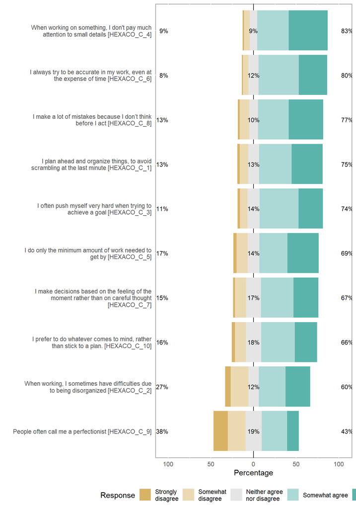

Likert plot of scale HEXACO_C items

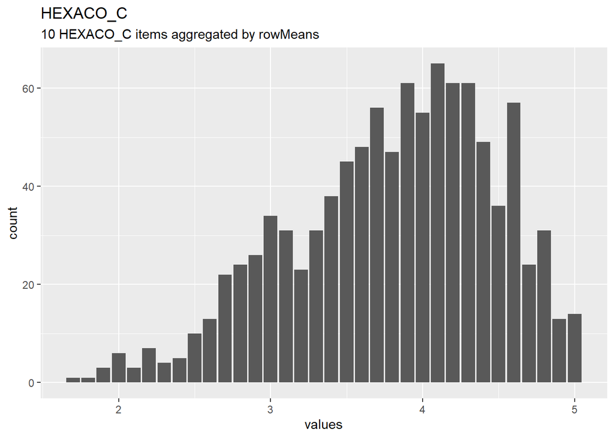

Distribution of scale HEXACO_C

#### Reliability details

```
## No viewer found, probably documenting or testing
```

##### Scale diagnosis

###### Reliability (internal consistency) estimates

##### Scale structure

###### Information about this scale

| Dataframe: | res$dat |
| --- | --- |
| Items: | HEXACO_C_1, HEXACO_C_2, HEXACO_C_3, HEXACO_C_4, HEXACO_C_5, HEXACO_C_6, HEXACO_C_7, HEXACO_C_8, HEXACO_C_9 & HEXACO_C_10 |
| Observations: | 1005 |
| Positive correlations: | 45 |
| Number of correlations: | 45 |
| Percentage positive correlations: | 100 |

###### Estimates assuming interval level

| Omega (total): | 0.86 |
| --- | --- |
| Omega (hierarchical): | 0.56 |
| Revelle’s Omega (total): | 0.86 |
| Greatest Lower Bound (GLB): | 0.87 |
| Coefficient H: | 0.85 |
| Coefficient Alpha: | 0.81 |

(Estimates assuming ordinal level not computed, as the polychoric correlation matrix has missing values.)

Note: the normal point estimate and confidence interval for omega are based on the procedure suggested by Dunn, Baguley & Brunsden (2013) using the MBESS function ci.reliability, whereas the psych package point estimate was suggested in Revelle & Zinbarg (2008). See the help (‘?ufs::scaleStructure’) for more information.

###### Eigen values

3.912, 1.361, 0.858, 0.785, 0.715, 0.687, 0.465, 0.443, 0.405 & 0.369

###### Factor analysis (reproducing only shared variance)

|  | ML1 | ML2 |
| --- | --- | --- |
| HEXACO_C_1 | 0.459 | 0.196 |
| HEXACO_C_2 | 0.509 | 0.148 |
| HEXACO_C_3 | -0.091 | 0.590 |
| HEXACO_C_4 | 0.395 | 0.358 |
| HEXACO_C_5 | 0.240 | 0.530 |
| HEXACO_C_6 | 0.008 | 0.579 |
| HEXACO_C_7 | 0.800 | -0.084 |
| HEXACO_C_8 | 0.706 | 0.066 |
| HEXACO_C_9 | -0.111 | 0.442 |
| HEXACO_C_10 | 0.763 | -0.034 |

###### Component analysis (reproducing full covariance matrix)

|  | TC1 | TC2 |
| --- | --- | --- |
| HEXACO_C_1 | 0.573 | 0.191 |
| HEXACO_C_2 | 0.689 | 0.014 |
| HEXACO_C_3 | -0.006 | 0.713 |
| HEXACO_C_4 | 0.560 | 0.285 |
| HEXACO_C_5 | 0.437 | 0.445 |
| HEXACO_C_6 | 0.125 | 0.663 |
| HEXACO_C_7 | 0.810 | -0.096 |
| HEXACO_C_8 | 0.809 | -0.024 |
| HEXACO_C_9 | -0.154 | 0.721 |
| HEXACO_C_10 | 0.801 | -0.062 |

###### Item descriptives

|  | mean | median | var | sd | IQR | se | min | q1 | q3 | max | skew | kurt | dip | n | NA | valid |
| --- | --- | --- | --- | --- | --- | --- | --- | --- | --- | --- | --- | --- | --- | --- | --- | --- |
| HEXACO_C_1 | 3.9532 | 4 | 1.1323 | 1.0641 | 2 | 0.0336 | 1 | 3 | 5 | 5 | -0.9554 | 0.205 | 0.1806 | 1005 | 0 | 1005 |
| HEXACO_C_2 | 3.5562 | 4 | 1.6395 | 1.2804 | 3 | 0.0404 | 1 | 2 | 5 | 5 | -0.4776 | -1.0197 | 0.1453 | 1005 | 0 | 1005 |
| HEXACO_C_3 | 3.8896 | 4 | 1.0067 | 1.0034 | 2 | 0.0316 | 1 | 3 | 5 | 5 | -0.9216 | 0.4284 | 0.1438 | 1005 | 0 | 1005 |
| HEXACO_C_4 | 4.1821 | 4 | 0.9459 | 0.9726 | 1 | 0.0307 | 1 | 2 | 5 | 5 | -1.2886 | 1.2266 | 0.1856 | 1005 | 0 | 1005 |
| HEXACO_C_5 | 3.8537 | 4 | 1.3421 | 1.1585 | 2 | 0.0365 | 1 | 2 | 5 | 5 | -0.795 | -0.3774 | 0.1647 | 1005 | 0 | 1005 |
| HEXACO_C_6 | 4.0458 | 4 | 0.8206 | 0.9059 | 1 | 0.0286 | 1 | 3 | 5 | 5 | -1.0085 | 0.8733 | 0.1662 | 1005 | 0 | 1005 |
| HEXACO_C_7 | 3.793 | 4 | 1.1424 | 1.0688 | 2 | 0.0337 | 1 | 3 | 5 | 5 | -0.6547 | -0.409 | 0.1463 | 1005 | 0 | 1005 |
| HEXACO_C_8 | 4.0169 | 4 | 1.1421 | 1.0687 | 1 | 0.0337 | 1 | 2 | 5 | 5 | -1.005 | 0.165 | 0.1811 | 1005 | 0 | 1005 |
| HEXACO_C_9 | 3.0279 | 3 | 1.7223 | 1.3124 | 2 | 0.0414 | 1 | 2 | 4 | 5 | -0.1336 | -1.1797 | 0.1045 | 1005 | 0 | 1005 |
| HEXACO_C_10 | 3.7134 | 4 | 1.2066 | 1.0985 | 2 | 0.0347 | 1 | 3 | 5 | 5 | -0.6753 | -0.3097 | 0.1303 | 1005 | 0 | 1005 |

###### Scattermatrix

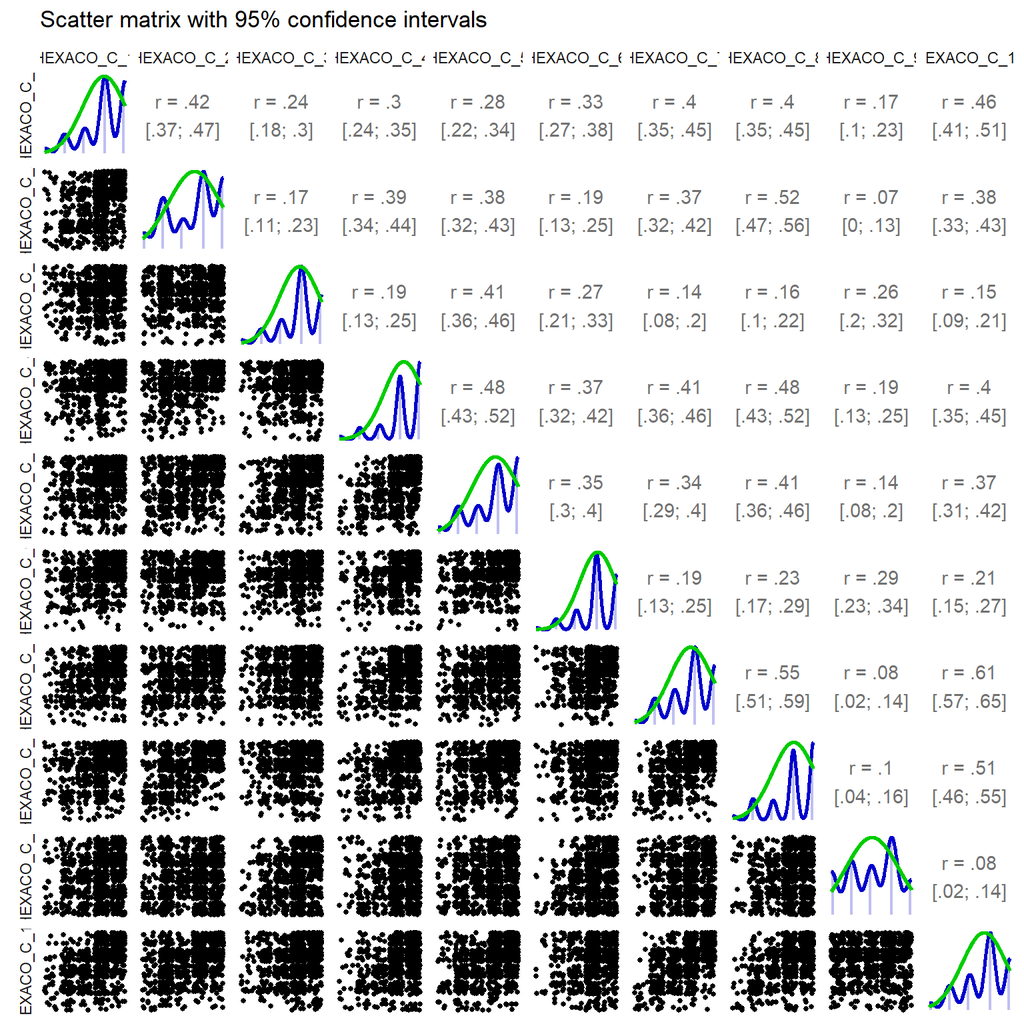

Scatterplot

```
## No viewer found, probably documenting or testing
```

#### Summary statistics

| name | label | data_type | value_labels | n_missing | complete_rate | min | median | max | mean | sd | n_value_labels | hist |
| --- | --- | --- | --- | --- | --- | --- | --- | --- | --- | --- | --- | --- |
| HEXACO_C_1 | I plan ahead and organize things, to avoid scrambling at the last minute | haven_labelled | 1. Strongly disagree, 2. Somewhat disagree, 3. Neither agree nor disagree, 4. Somewhat agree, 5. Strongly agree | 33 | 0.9682387 | 1 | 4 | 5 | 3.950298 | 1.0676216 | 5 | ▁▂▁▂▁▇▁▇ |
| HEXACO_C_2 | When working, I sometimes have difficulties due to being disorganized | haven_labelled | 5. Strongly disagree, 4. Somewhat disagree, 3. Neither agree nor disagree, 2. Somewhat agree, 1. Strongly agree | 33 | 0.9682387 | 1 | 4 | 5 | 3.555666 | 1.2799186 | 5 | ▂▅▁▃▁▇▁▇ |
| HEXACO_C_3 | I often push myself very hard when trying to achieve a goal | haven_labelled | 1. Strongly disagree, 2. Somewhat disagree, 3. Neither agree nor disagree, 4. Somewhat agree, 5. Strongly agree | 33 | 0.9682387 | 1 | 4 | 5 | 3.889662 | 1.0028578 | 5 | ▁▂▁▂▁▇▁▅ |
| HEXACO_C_4 | When working on something, I don’t pay much attention to small details | haven_labelled | 5. Strongly disagree, 4. Somewhat disagree, 3. Neither agree nor disagree, 2. Somewhat agree, 1. Strongly agree | 33 | 0.9682387 | 1 | 4 | 5 | 4.180915 | 0.9728010 | 5 | ▁▁▁▂▁▆▁▇ |
| HEXACO_C_5 | I do only the minimum amount of work needed to get by | haven_labelled | 5. Strongly disagree, 4. Somewhat disagree, 3. Neither agree nor disagree, 2. Somewhat agree, 1. Strongly agree | 34 | 0.9672762 | 1 | 4 | 5 | 3.853731 | 1.1585033 | 5 | ▁▃▁▃▁▇▁▇ |
| HEXACO_C_6 | I always try to be accurate in my work, even at the expense of time | haven_labelled | 1. Strongly disagree, 2. Somewhat disagree, 3. Neither agree nor disagree, 4. Somewhat agree, 5. Strongly agree | 33 | 0.9682387 | 1 | 4 | 5 | 4.045726 | 0.9054268 | 5 | ▁▁▁▂▁▇▁▆ |
| HEXACO_C_7 | I make decisions based on the feeling of the moment rather than on careful thought | haven_labelled | 5. Strongly disagree, 4. Somewhat disagree, 3. Neither agree nor disagree, 2. Somewhat agree, 1. Strongly agree | 33 | 0.9682387 | 1 | 4 | 5 | 3.792247 | 1.0685833 | 5 | ▁▃▁▃▁▇▁▆ |
| HEXACO_C_8 | I make a lot of mistakes because I don’t think before I act | haven_labelled | 5. Strongly disagree, 4. Somewhat disagree, 3. Neither agree nor disagree, 2. Somewhat agree, 1. Strongly agree | 33 | 0.9682387 | 1 | 4 | 5 | 4.014911 | 1.0700706 | 5 | ▁▂▁▂▁▇▁▇ |
| HEXACO_C_9 | People often call me a perfectionist | haven_labelled | 1. Strongly disagree, 2. Somewhat disagree, 3. Neither agree nor disagree, 4. Somewhat agree, 5. Strongly agree | 34 | 0.9672762 | 1 | 3 | 5 | 3.027861 | 1.3123759 | 5 | ▅▆▁▅▁▇▁▃ |
| HEXACO_C_10 | I prefer to do whatever comes to mind, rather than stick to a plan. | haven_labelled | 5. Strongly disagree, 4. Somewhat disagree, 3. Neither agree nor disagree, 2. Somewhat agree, 1. Strongly agree | 33 | 0.9682387 | 1 | 4 | 5 | 3.714712 | 1.0986750 | 5 | ▁▂▁▃▁▇▁▅ |

### Scale: Organization

#### Overview

**Missing**: 33.

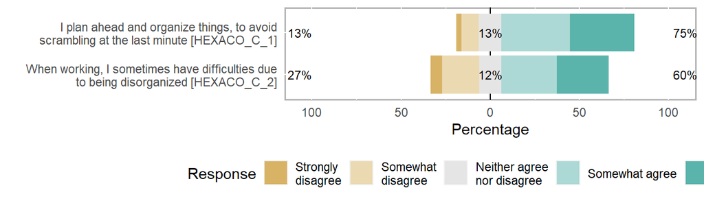

Likert plot of scale Organization items

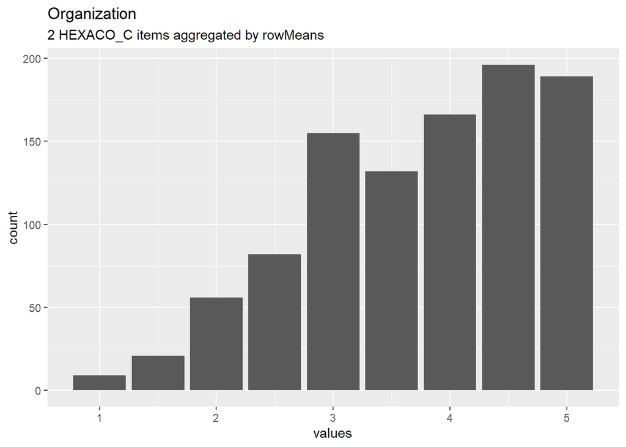

Distribution of scale Organization

#### Reliability details

```
## No viewer found, probably documenting or testing
```

##### Scale diagnosis

###### Reliability (internal consistency) estimates

##### Scale structure

###### Information about this scale

| Dataframe: | res$dat |
| --- | --- |
| Items: | HEXACO_C_1 & HEXACO_C_2 |
| Observations: | 1006 |
| Positive correlations: | 1 |
| Number of correlations: | 1 |
| Percentage positive correlations: | 100 |

###### Estimates assuming interval level

###### Estimates for two-item measures

| Spearman Brown coefficient: | 0.59 |
| --- | --- |
| Coefficient Alpha: | 0.58 |
| Pearson Correlation: | 0.42 |

###### Eigen values

1.419 & 0.581

###### Item descriptives

|  | mean | median | var | sd | IQR | se | min | q1 | q3 | max | skew | kurt | dip | n | NA | valid |
| --- | --- | --- | --- | --- | --- | --- | --- | --- | --- | --- | --- | --- | --- | --- | --- | --- |
| HEXACO_C_1 | 3.9503 | 4 | 1.1398 | 1.0676 | 2 | 0.0337 | 1 | 2.5 | 5 | 5 | -0.9578 | 0.2074 | 0.1804 | 1006 | 0 | 1006 |
| HEXACO_C_2 | 3.5557 | 4 | 1.6382 | 1.2799 | 3 | 0.0404 | 1 | 2 | 5 | 5 | -0.4765 | -1.0193 | 0.1451 | 1006 | 0 | 1006 |

###### Scattermatrix

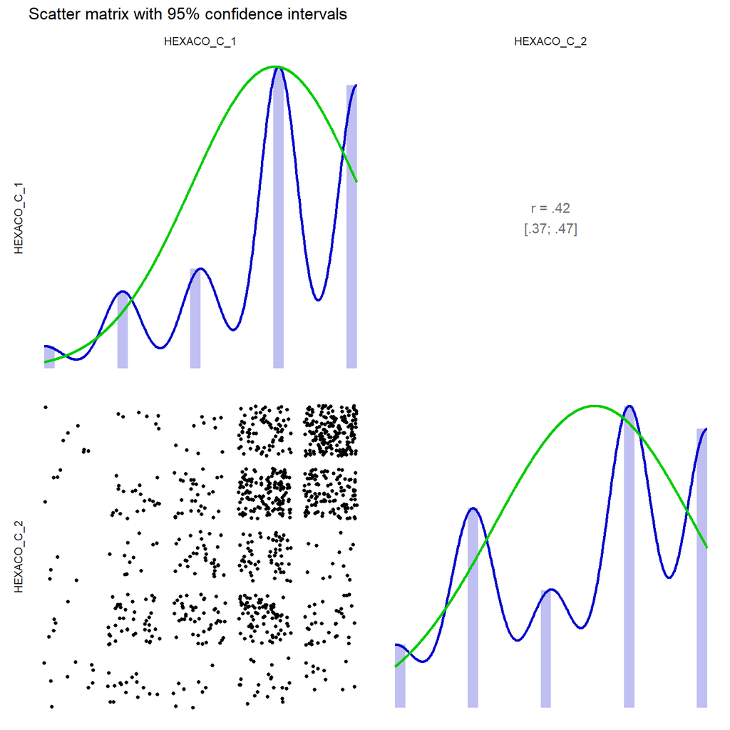

Scatterplot

```
## No viewer found, probably documenting or testing
```

#### Summary statistics

| name | label | data_type | value_labels | n_missing | complete_rate | min | median | max | mean | sd | n_value_labels | hist |
| --- | --- | --- | --- | --- | --- | --- | --- | --- | --- | --- | --- | --- |
| HEXACO_C_1 | I plan ahead and organize things, to avoid scrambling at the last minute | haven_labelled | 1. Strongly disagree, 2. Somewhat disagree, 3. Neither agree nor disagree, 4. Somewhat agree, 5. Strongly agree | 33 | 0.9682387 | 1 | 4 | 5 | 3.950298 | 1.067622 | 5 | ▁▂▁▂▁▇▁▇ |
| HEXACO_C_2 | When working, I sometimes have difficulties due to being disorganized | haven_labelled | 5. Strongly disagree, 4. Somewhat disagree, 3. Neither agree nor disagree, 2. Somewhat agree, 1. Strongly agree | 33 | 0.9682387 | 1 | 4 | 5 | 3.555666 | 1.279919 | 5 | ▂▅▁▃▁▇▁▇ |

### Scale: Diligence

#### Overview

**Missing**: 34.

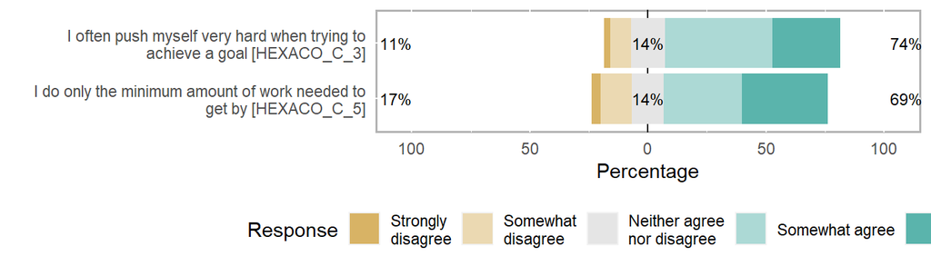

Likert plot of scale Diligence items

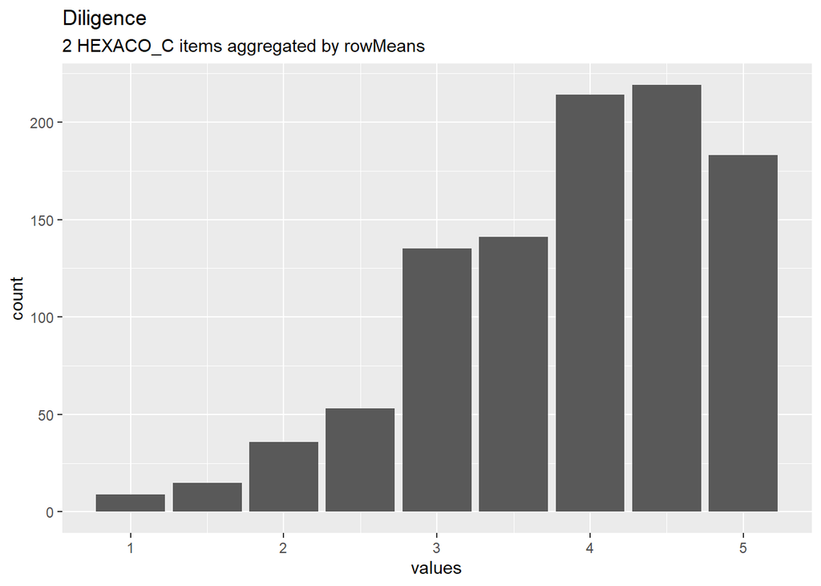

Distribution of scale Diligence

#### Reliability details

```
## No viewer found, probably documenting or testing
```

##### Scale diagnosis

###### Reliability (internal consistency) estimates

##### Scale structure

###### Information about this scale

| Dataframe: | res$dat |
| --- | --- |
| Items: | HEXACO_C_3 & HEXACO_C_5 |
| Observations: | 1005 |
| Positive correlations: | 1 |
| Number of correlations: | 1 |
| Percentage positive correlations: | 100 |

###### Estimates assuming interval level

###### Estimates for two-item measures

| Spearman Brown coefficient: | 0.58 |
| --- | --- |
| Coefficient Alpha: | 0.58 |
| Pearson Correlation: | 0.41 |

###### Eigen values

1.411 & 0.589

###### Item descriptives

|  | mean | median | var | sd | IQR | se | min | q1 | q3 | max | skew | kurt | dip | n | NA | valid |
| --- | --- | --- | --- | --- | --- | --- | --- | --- | --- | --- | --- | --- | --- | --- | --- | --- |
| HEXACO_C_3 | 3.8896 | 4 | 1.0067 | 1.0034 | 2 | 0.0316 | 1 | 3 | 5 | 5 | -0.9216 | 0.4284 | 0.1438 | 1005 | 0 | 1005 |
| HEXACO_C_5 | 3.8537 | 4 | 1.3421 | 1.1585 | 2 | 0.0365 | 1 | 2 | 5 | 5 | -0.795 | -0.3774 | 0.1647 | 1005 | 0 | 1005 |

###### Scattermatrix

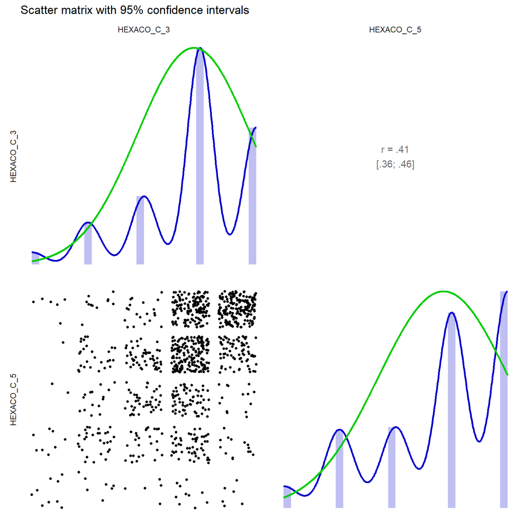

Scatterplot

```
## No viewer found, probably documenting or testing
```

#### Summary statistics

| name | label | data_type | value_labels | n_missing | complete_rate | min | median | max | mean | sd | n_value_labels | hist |
| --- | --- | --- | --- | --- | --- | --- | --- | --- | --- | --- | --- | --- |
| HEXACO_C_3 | I often push myself very hard when trying to achieve a goal | haven_labelled | 1. Strongly disagree, 2. Somewhat disagree, 3. Neither agree nor disagree, 4. Somewhat agree, 5. Strongly agree | 33 | 0.9682387 | 1 | 4 | 5 | 3.889662 | 1.002858 | 5 | ▁▂▁▂▁▇▁▅ |
| HEXACO_C_5 | I do only the minimum amount of work needed to get by | haven_labelled | 5. Strongly disagree, 4. Somewhat disagree, 3. Neither agree nor disagree, 2. Somewhat agree, 1. Strongly agree | 34 | 0.9672762 | 1 | 4 | 5 | 3.853731 | 1.158503 | 5 | ▁▃▁▃▁▇▁▇ |

### Scale: Perfectionism

#### Overview

**Missing**: 34.

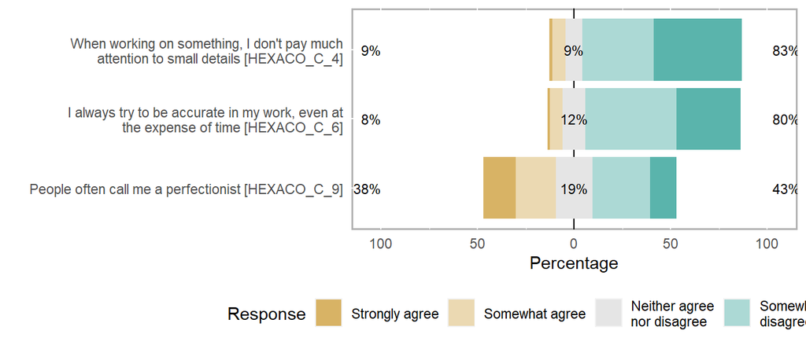

Likert plot of scale Perfectionism items

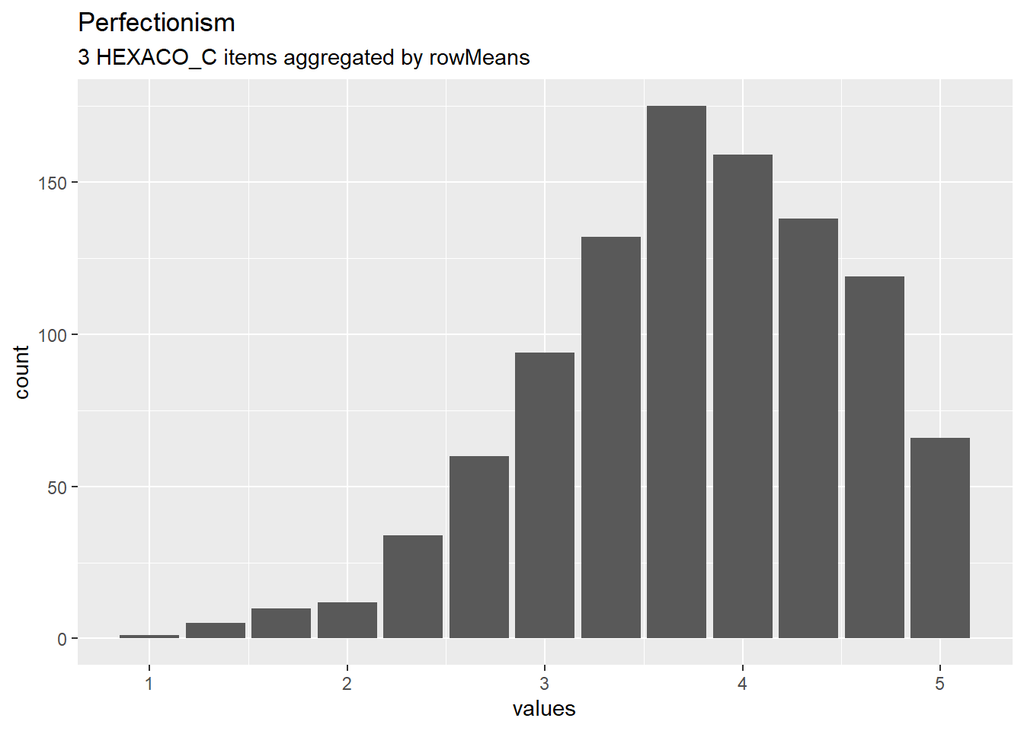

Distribution of scale Perfectionism

#### Reliability details

```
## No viewer found, probably documenting or testing
```

##### Scale diagnosis

###### Reliability (internal consistency) estimates

##### Scale structure

###### Information about this scale

| Dataframe: | res$dat |
| --- | --- |
| Items: | HEXACO_C_4, HEXACO_C_6 & HEXACO_C_9 |
| Observations: | 1005 |
| Positive correlations: | 3 |
| Number of correlations: | 3 |
| Percentage positive correlations: | 100 |

###### Estimates assuming interval level

| Omega (total): | 0.57 |
| --- | --- |
| Omega (hierarchical): | 0.02 |
| Revelle’s Omega (total): | 0.57 |
| Greatest Lower Bound (GLB): | 0.60 |
| Coefficient H: | 0.64 |
| Coefficient Alpha: | 0.51 |

(Estimates assuming ordinal level not computed, as the polychoric correlation matrix has missing values.)

Note: the normal point estimate and confidence interval for omega are based on the procedure suggested by Dunn, Baguley & Brunsden (2013) using the MBESS function ci.reliability, whereas the psych package point estimate was suggested in Revelle & Zinbarg (2008). See the help (‘?ufs::scaleStructure’) for more information.

###### Eigen values

1.572, 0.818 & 0.61

###### Factor analysis (reproducing only shared variance)

|  | ML1 |
| --- | --- |
| HEXACO_C_4 | 0.497 |
| HEXACO_C_6 | 0.746 |
| HEXACO_C_9 | 0.385 |

###### Component analysis (reproducing full covariance matrix)

|  | PC1 |
| --- | --- |
| HEXACO_C_4 | 0.728 |
| HEXACO_C_6 | 0.794 |
| HEXACO_C_9 | 0.642 |

###### Item descriptives

|  | mean | median | var | sd | IQR | se | min | q1 | q3 | max | skew | kurt | dip | n | NA | valid |
| --- | --- | --- | --- | --- | --- | --- | --- | --- | --- | --- | --- | --- | --- | --- | --- | --- |
| HEXACO_C_4 | 4.1821 | 4 | 0.9459 | 0.9726 | 1 | 0.0307 | 1 | 2 | 5 | 5 | -1.2886 | 1.2266 | 0.1856 | 1005 | 0 | 1005 |
| HEXACO_C_6 | 4.0458 | 4 | 0.8206 | 0.9059 | 1 | 0.0286 | 1 | 3 | 5 | 5 | -1.0085 | 0.8733 | 0.1662 | 1005 | 0 | 1005 |
| HEXACO_C_9 | 3.0279 | 3 | 1.7223 | 1.3124 | 2 | 0.0414 | 1 | 2 | 4 | 5 | -0.1336 | -1.1797 | 0.1045 | 1005 | 0 | 1005 |

###### Scattermatrix

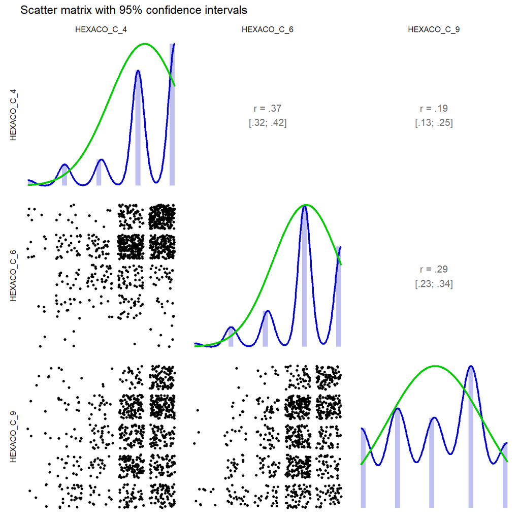

Scatterplot

```
## No viewer found, probably documenting or testing
```

#### Summary statistics

| name | label | data_type | value_labels | n_missing | complete_rate | min | median | max | mean | sd | n_value_labels | hist |
| --- | --- | --- | --- | --- | --- | --- | --- | --- | --- | --- | --- | --- |
| HEXACO_C_4 | When working on something, I don’t pay much attention to small details | haven_labelled | 5. Strongly disagree, 4. Somewhat disagree, 3. Neither agree nor disagree, 2. Somewhat agree, 1. Strongly agree | 33 | 0.9682387 | 1 | 4 | 5 | 4.180915 | 0.9728010 | 5 | ▁▁▁▂▁▆▁▇ |
| HEXACO_C_6 | I always try to be accurate in my work, even at the expense of time | haven_labelled | 1. Strongly disagree, 2. Somewhat disagree, 3. Neither agree nor disagree, 4. Somewhat agree, 5. Strongly agree | 33 | 0.9682387 | 1 | 4 | 5 | 4.045726 | 0.9054268 | 5 | ▁▁▁▂▁▇▁▆ |
| HEXACO_C_9 | People often call me a perfectionist | haven_labelled | 1. Strongly disagree, 2. Somewhat disagree, 3. Neither agree nor disagree, 4. Somewhat agree, 5. Strongly agree | 34 | 0.9672762 | 1 | 3 | 5 | 3.027861 | 1.3123759 | 5 | ▅▆▁▅▁▇▁▃ |

### Scale: Prudence

#### Overview

**Missing**: 33.

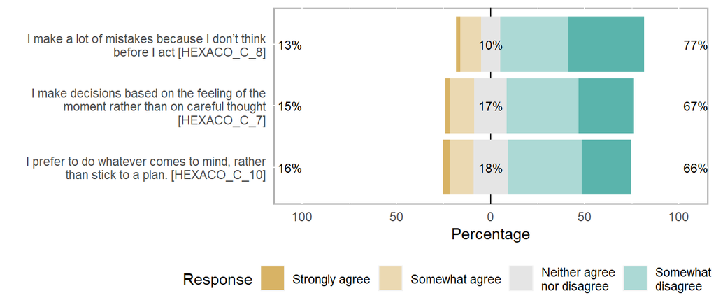

Likert plot of scale Prudence items

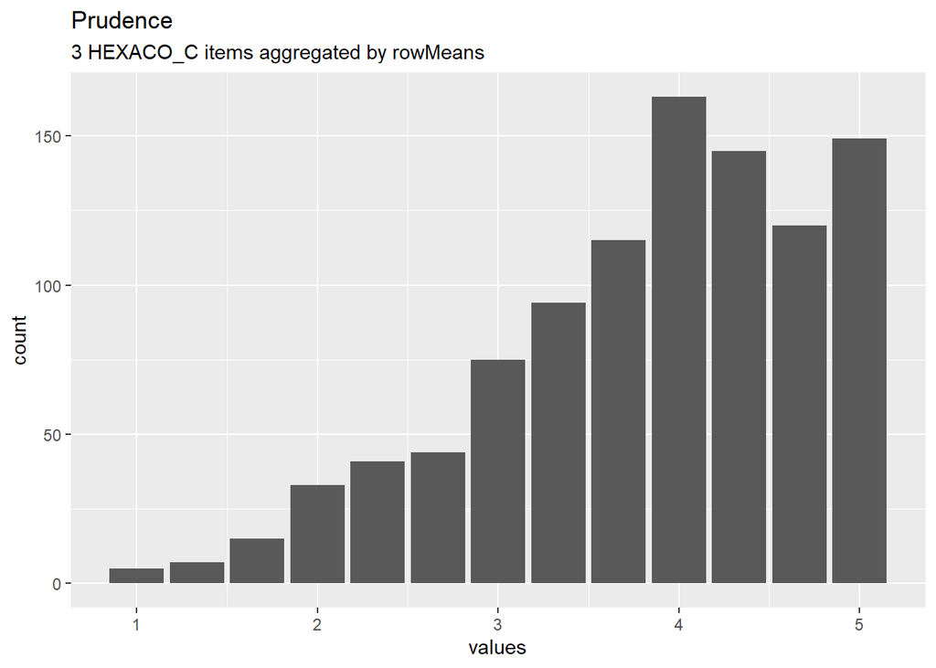

Distribution of scale Prudence

#### Reliability details

```
## No viewer found, probably documenting or testing
```

##### Scale diagnosis

###### Reliability (internal consistency) estimates

##### Scale structure

###### Information about this scale

| Dataframe: | res$dat |
| --- | --- |
| Items: | HEXACO_C_7, HEXACO_C_8 & HEXACO_C_10 |
| Observations: | 1006 |
| Positive correlations: | 3 |
| Number of correlations: | 3 |
| Percentage positive correlations: | 100 |

###### Estimates assuming interval level

| Omega (total): | 0.79 |
| --- | --- |
| Omega (hierarchical): | 0.04 |
| Revelle’s Omega (total): | 0.79 |
| Greatest Lower Bound (GLB): | 0.80 |
| Coefficient H: | 0.80 |
| Coefficient Alpha: | 0.79 |

(Estimates assuming ordinal level not computed, as the polychoric correlation matrix has missing values.)

Note: the normal point estimate and confidence interval for omega are based on the procedure suggested by Dunn, Baguley & Brunsden (2013) using the MBESS function ci.reliability, whereas the psych package point estimate was suggested in Revelle & Zinbarg (2008). See the help (‘?ufs::scaleStructure’) for more information.

###### Eigen values

2.111, 0.504 & 0.385

###### Factor analysis (reproducing only shared variance)

|  | ML1 |
| --- | --- |
| HEXACO_C_7 | 0.814 |
| HEXACO_C_8 | 0.677 |
| HEXACO_C_10 | 0.747 |

###### Component analysis (reproducing full covariance matrix)

|  | PC1 |
| --- | --- |
| HEXACO_C_7 | 0.863 |
| HEXACO_C_8 | 0.811 |
| HEXACO_C_10 | 0.842 |

###### Item descriptives

|  | mean | median | var | sd | IQR | se | min | q1 | q3 | max | skew | kurt | dip | n | NA | valid |
| --- | --- | --- | --- | --- | --- | --- | --- | --- | --- | --- | --- | --- | --- | --- | --- | --- |
| HEXACO_C_7 | 3.7922 | 4 | 1.1419 | 1.0686 | 2 | 0.0337 | 1 | 3 | 5 | 5 | -0.6526 | -0.4109 | 0.1461 | 1006 | 0 | 1006 |
| HEXACO_C_8 | 4.0149 | 4 | 1.1451 | 1.0701 | 1 | 0.0337 | 1 | 2 | 5 | 5 | -1.0012 | 0.1508 | 0.1809 | 1006 | 0 | 1006 |
| HEXACO_C_10 | 3.7147 | 4 | 1.2071 | 1.0987 | 2 | 0.0346 | 1 | 3 | 5 | 5 | -0.6761 | -0.3094 | 0.1307 | 1006 | 0 | 1006 |

###### Scattermatrix

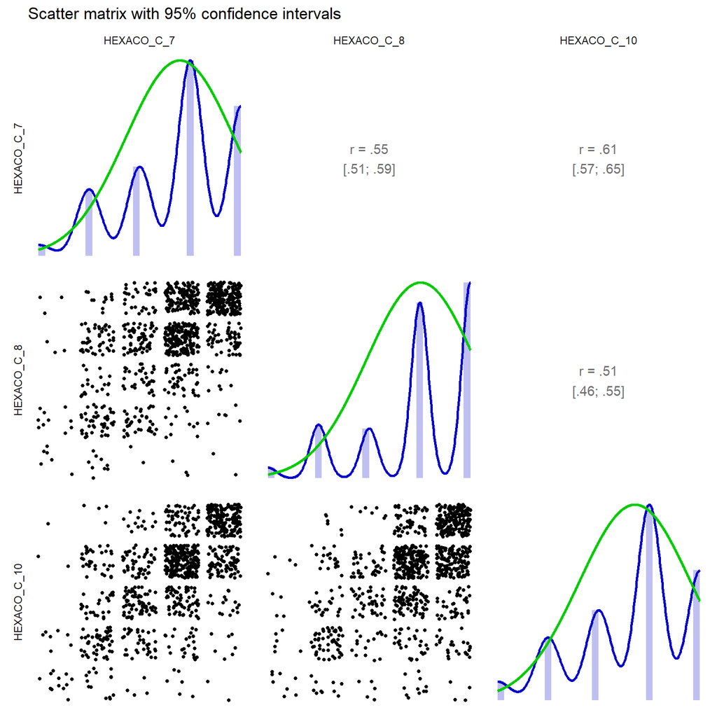

Scatterplot

```
## No viewer found, probably documenting or testing
```

#### Summary statistics

| name | label | data_type | value_labels | n_missing | complete_rate | min | median | max | mean | sd | n_value_labels | hist |
| --- | --- | --- | --- | --- | --- | --- | --- | --- | --- | --- | --- | --- |
| HEXACO_C_7 | I make decisions based on the feeling of the moment rather than on careful thought | haven_labelled | 5. Strongly disagree, 4. Somewhat disagree, 3. Neither agree nor disagree, 2. Somewhat agree, 1. Strongly agree | 33 | 0.9682387 | 1 | 4 | 5 | 3.792247 | 1.068583 | 5 | ▁▃▁▃▁▇▁▆ |
| HEXACO_C_8 | I make a lot of mistakes because I don’t think before I act | haven_labelled | 5. Strongly disagree, 4. Somewhat disagree, 3. Neither agree nor disagree, 2. Somewhat agree, 1. Strongly agree | 33 | 0.9682387 | 1 | 4 | 5 | 4.014911 | 1.070071 | 5 | ▁▂▁▂▁▇▁▇ |
| HEXACO_C_10 | I prefer to do whatever comes to mind, rather than stick to a plan. | haven_labelled | 5. Strongly disagree, 4. Somewhat disagree, 3. Neither agree nor disagree, 2. Somewhat agree, 1. Strongly agree | 33 | 0.9682387 | 1 | 4 | 5 | 3.714712 | 1.098675 | 5 | ▁▂▁▃▁▇▁▅ |

## Missingness report

| description | DGS_1 | DGS_2 | DGS_3 | DGS_4 | DGS_5 | DGS_6 | DGS_7 | DGS_9 | DGS_10 | DGS_11 | DGS_14 | DGS_15 | DGS_17 | DGS_19 | DGS_20 | DGS_21 | DGS_22 | DGS_23 | DGS_24 | DGS_25 | DGS_26 | DGS_27 | DGS_28 | DGS_29 | DGS_30 | DGS_31 | DGS_32 | DGS_34 | DGS_35 | … |
| --- | --- | --- | --- | --- | --- | --- | --- | --- | --- | --- | --- | --- | --- | --- | --- | --- | --- | --- | --- | --- | --- | --- | --- | --- | --- | --- | --- | --- | --- | --- |
| Missing values per variable | 33 | 33 | 33 | 33 | 33 | 33 | 33 | 33 | 33 | 33 | 33 | 33 | 33 | 33 | 33 | 33 | 33 | 33 | 33 | 33 | 33 | 33 | 33 | 33 | 33 | 33 | 33 | 33 | 33 | … |
| Missing values in 0 variables | 1 | 1 | 1 | 1 | 1 | 1 | 1 | 1 | 1 | 1 | 1 | 1 | 1 | 1 | 1 | 1 | 1 | 1 | 1 | 1 | 1 | 1 | 1 | 1 | 1 | 1 | 1 | 1 | 1 | … |
| Missing values in 97 variables | 0 | 0 | 0 | 0 | 0 | 0 | 0 | 0 | 0 | 0 | 0 | 0 | 0 | 0 | 0 | 0 | 0 | 0 | 0 | 0 | 0 | 0 | 0 | 0 | 0 | 0 | 0 | 0 | 0 | … |
| Missing values in 1 variables | 1 | 1 | 1 | 1 | 1 | 1 | 1 | 1 | 1 | 1 | 1 | 1 | 1 | 1 | 1 | 1 | 1 | 1 | 1 | 1 | 1 | 1 | 1 | 1 | 1 | 1 | 1 | 1 | 1 | … |
| 11 other, less frequent patterns | 11 | 11 | 11 | 11 | 11 | 11 | 11 | 11 | 11 | 11 | 11 | 11 | 11 | 11 | 11 | 11 | 11 | 11 | 11 | 11 | 11 | 11 | 11 | 11 | 11 | 11 | 11 | 11 | 11 | … |